# Etude de marché sur le poulet

[figure not shown]

## Mon objectif

Aider à cibler certains pays pour l'exportation de poulets, dans le but d'approfondir mes analyses ensuite dans une étude de marché de plus grande envergure. Afin d'y parvenir, il faudrait grouper les pays qui ont des caractéristiques communes dans des ensembles plus ou moins grands.

## Synthèse des informations existantes sur le sujet

Même si cela peut paraître trivial, commençons par la définition du poulet pour s'assurer d'éviter toute confusion. Selon le CNRTL, c'est un:

> Jeune coq ou jeune poule, élevé pour la consommation précoce.

La *FAO* nous révèle l'importance croisssante de cet animal :

> Les poulets (Gallus gallus domesticus) ont été domestiqués à partir du coq doré (Gallus gallus) en Asie il y a environ 5000 ans. Les poulets sont sans aucun doute l'espèce de bétail domestique la plus répandue et la plus abondante et sont présents plus ou moins partout où habite l'être humain. Dans les systèmes d'élevage intensifs, ils ont tendance à être élevés pour leurs œufs (pondeuses) ou la viande (poulets de chair), mais dans les systèmes à petite échelle, ils tendent à avoir un double objectif. Avec des cycles de vie courts et des taux de conversion alimentaire potentiellement élevés, la production de poulet peut être rapidement augmentée pour répondre à la demande croissante d'aliments d'origine animale. Ils constituent donc le sous-secteur de l'élevage dont la croissance est la plus rapide.

Sur son site, la *FAO* nous informe également de sa répartition. Sur la carte ci-dessous, on peut voir le nombre de poulets par kilomètre carré en 2010. On peut y déceler les principales régions productrices de poulet.

[figure not shown]

Concernant la production, dans le cadre du *GLEAM 2.0*, la *FAO* nous indique que :

> Les produits d’origine animale peuvent être exprimés en quantité de protéine, ce qui permet les comparaisons entre les espèces et produits. L’Asie de l’Est et du Sud-Est, avec environ 19 millions de tonnes de protéines, est la première région productrice de produits animaux, principalement basée sur l’élevage de monogastriques. L’Europe de l’Ouest, l’Amérique du Nord l’Amérique latine et les Caraïbes et l’Asie du Sud ont des niveaux de production comparables, entre 12 et 10 millions de tonnes de protéines. Cependant, leurs profils sont différents: alors que la viande bovine, le lait et le poulet jouent un rôle principal en Amérique latine et du Nord, le secteur bovin laitier domine en Europe de l’Ouest et la production de buffle joue un rôle important en Asie du Sud. Le moyen Orient, l’Afrique du nord et sub-saharienne, l’Europe de l'Est, l’Océanie et la Fédération de Russie, avec une production entre 4 et 1,6 millions de tonnes de protéines, ont chacune une part individuelle plus faible à l'échelle mondiale.

Ces éléments sont essentiels pour notre analyse. Nous savons qu'il est judicieux **d'exprimer les produits animaliers en termes de protéines** ; nous avons des informations sur les profils des pays qui nous aideront à mieux classifier et interpréter l'ACP. Il semble judicieux d'**inclure des indices indiquant le niveau de production** de chaque pays pour notre ACP. L'institution internationale nous fournit également la carte située ci-dessous.

[figure not shown]

L'*OCDE* a publié un rapport très intéressant pour notre étude en 2018, il s'intitule "Market examinations in Mexico - CASE STUDY OF THE CHICKEN MEAT MARKET" Vous pouvez le télécharger en cliquant dans le lien adéquat situé dans les sources. C'est surtout le deuxième chapitre qui est d'intérêt puisqu'il traite des tendances internationales. Nous y apprenons que :

- "La consommation de viande a augmenté régulièrement pendant plusieurs décennies. Les raisons en sont la croissance de la population et le revenu moyen, ce qui a permis de passer d'un régime à base de céréales à un régime dans lequel la consommation de viande est plus importante."
- D'ici 2030, la viande de poulet sera la première source de protéines animales, soit 38% du total des protéines animales consommées. -> Nous sommes sur un **marché en croissance**.
- Les raisons de cette prévision sont les suivantes:
  - Le prix de la volaille est inférieur à celui de la viande rouge. -> Peut être vérifié dans l'étude approfondie.
  - Le processus de croissance des oiseaux sont plus courts que ceux des autres espèces.
  - Ils sont produits plus efficacement. -> Cela est en adéquation avec ce qui écrit dans le *GLEAM 2.0* dans la partie "Émissions par produit et intensités d'émission".
  - Les consommateurs ont une perception favorable de leurs propriétés nutritionnelles. -> Important mais je ne pense pas pouvoir le prendre en compte quantitativement dans mon analyse.
  - Il n'y a pratiquement aucune restriction religieuse à la consommation de poulet. -> Important mais je ne pense pas pouvoir le prendre en compte quantitativement dans mon analyse.
- La consommation de viande par habitant a augmenté de 24% entre 1995 et 2015 et devrait encore augmenter de 3,5% entre 2015 et 2025.
- "Il est possible que la consommation augmente plus rapidement dans les pays à revenu faible ou intermédiaire en pleine croissance économique." -> **Ajouter un attribut indiquant le croissance économique du pays et sa puissance économique actuelle tel que le PIB.**
- Entre 1995 et 2015, la viande de volaille est passée de 31% de la consommation de viande par habitant à près de 40%.
- Les pays en développement devraient enregistrer une augmentation totale de la consommation de viande de 5,4% et de 6,9% de la viande de volaille. -> **Détecter les pays en dévelopement** dans mon analyse car ils semblent être une **bonne cible pour l'export**.
- "Dans le cas du poulet, en 1925, il fallait 112 jours (16 semaines) d'élevage pour obtenir des animaux pesant en moyenne environ 1 kg. Les données les plus récentes indiquent qu'il faut actuellement près de 7 semaines pour obtenir des oiseaux pesant 2,8 kg."

Sur le sujet de la consommation, dans un rapport de 2003 ("World agriculture: towards 2015/2030 - AN FAO PERSPECTIVE"), la FAO avait prédit que :

> L'un des facteurs qui déterminent l'évolution future du commerce mondial de la viande est la spécialisation continue de la production et de la transformation. La spécialisation croissante de la production, motivée par les préférences des consommateurs pour des types et des découpes de viande spécifiques, aura pour conséquence que les pays commercialisent différents types de découpes de viande.(...) La Chine importe des pieds et des ailes de poulet et exporte des coupes de viande transformées de plus grande valeur au Japon, en utilisant parfois des coupes importées moins chères d'autres pays. La différenciation croissante des produits en réponse aux préférences variées des différents marchés s'accélérera à mesure que les consommateurs deviendront plus exigeants, ce qui conduira à une économie de la viande plus complexe et diversifiée.

Ce dernier point est essentiel pour l'approfondissement de l'étude de marché qui sera entreprise après avoir aidé à cibler certains pays.

Sources :

- http://www.fao.org/gleam/results/fr/
- http://www.cnrtl.fr/definition/poulet
- http://www.fao.org/livestock-systems/production-systems/chicken/fr/
- https://fr.wikipedia.org/wiki/Coq_dor%C3%A9
- https://www.oecd.org/daf/competition/ENG-WEB-REPORT-Chicken-MeatMarketMexico2018.pdf
- http://www.agri-outlook.org/Agricultural-Outlook-2018.pdf
- http://www.fao.org/3/a-y4252e.pdf

## Choix des données

Remarques :

- Je me suis procuré les données de la FAO sur cette page : http://www.fao.org/faostat/fr/#data
- Sauf indication contraire, j'ai téléchargé des données concernant les années 2007 à 2016.
- Les clés primaires sont indiquées pour chacun des fichiers du dataset en dessous de chaque description de fichier.

Voici la liste des fichiers que j'ai choisie :

- **population.csv** (Population) : Permet de suivre l'évolution de la population de chaque pays et de créer la variable qui fait la différence de population entre une année antérieure (au choix) et l'année courante (exprimée en pourcentage). Il y a également la notion de population rurale et urbaine pouvant aider à caractériser un pays.
  - Zone
  - Année
- **bilans*alim**.csv** (Bilans Alimentaires) : Nous donne accès à des informations essentielles : disponibilité alimentaire en protéines par habitant, la disponibilité alimentaire en calories par habitant. Par conséquent, on utilisera ces données pour notre dataframe principale. J'ai téléchargé les données pour l'année 2013 (la dernière disponible), 2012 et 2011. Il y a un fichier par année à cause de limitations du site de la FAO.
  - Zone
  - Élément
  - Produit
  - Année
- **groupe_pays.csv** (Bilans Alimentaires - Définitions et Standards) : Pour connaître à quel continent/ groupe de pays appartient un pays.
  - Groupe de pays
  - Pays
- **groupe_produits.csv** (Bilans Alimentaires - Définitions et Standards) : Le fichier est utile pour connaître la proportion de protéines d'origine animale par rapport à la quantité totale de protéines dans la disponibilité alimentaire du pays.
  - Groupe de produits
  - Produits
- **macro.csv** (Indicateurs macro) : Le fichier fournit trois indicateurs macroéconomiques : le produit intérieur brut, le produit intérieur brut par habitant, la formation brute de capitale fixe. Il existe plusieurs manières de définir le PIB qui représente bien la puissance économique d'un Etat. Selon l'INSEE, le PIB "est égal à la somme des valeurs ajoutées brutes des différents secteurs institutionnels ou des différentes branches d'activité, augmentée des impôts moins les subventions sur les produits (lesquels ne sont pas affectés aux secteurs et aux branches d'activité)." Concernant la FBCF, pour l'INSEE elle "est constituée par les acquisitions moins cessions d'actifs fixes réalisées par les producteurs résidents. Les actifs fixes sont les actifs corporels ou incorporels issus de processus de production et utilisés de façon répétée ou continue dans d'autres processus de production pendant au moins un an". Investopedia nous explique que plus la FBCF est élevée plus une économie peut augmenter rapidement son revenu global. Pour notre analyse j'ai joint la notion de croissance annuelle pour chaque indicateur en plus de leur valeur réelle.
  - Zone
  - Élément
  - Produit
  - Année
- **ide.csv** (L’investissement Direct étranger) : Le fichier donne les entrées et les sorties d'IDE de chaque pays, les entrées sont un bon indicateur de l'attractivité du territoire, le sorties de sa santé économique. D'après l'INSEE, les IDE sont des "investissements qu'une unité institutionnelle résidente d'une économie effectue dans le but d'acquérir un intérêt durable dans une unité institutionnelle résidente d'une autre économie et d'exercer, dans le cadre d'une relation à long terme, une influence significative sur sa gestion. Par convention, une relation d'investissement direct est établie dès lors qu'un investisseur acquiert au moins 10 % du capital social de l'entreprise investie."
  - Zone
  - Élément
  - Produit
  - Année

## Chargement et préparation des données

### Dataframe principale

Création des attributs suivants pour l'ACP :

- Proportion de protéines d'origine animale par rapport à la quantité totale de protéines dans la disponibilité alimentaire du pays (Obligatoire)
- Disponibilité alimentaire en protéines par habitant
- Disponibilité alimentaire en calories par habitant

```python
# Manipulation
import numpy as np
import pandas as pd

# Visualisation
import matplotlib.pyplot as plt
import seaborn as sns

# Modélisation
from sklearn import decomposition # Regroupe les algos de décompositions matricielles, utilisé pour l'ACP
from sklearn import preprocessing # Pour centrer et réduire les données
from sklearn.cluster import KMeans
from scipy.cluster.hierarchy import dendrogram, linkage, fcluster # Pour le regroupement hiérarchique
```

```python
# Préparation de la table principale
df_fbs = pd.read_csv('Data\\bilans_alim_2013.csv')

# Visualisation de la table
df_fbs.info()
df_fbs.head(10)
```

```
<class 'pandas.core.frame.DataFrame'>
RangeIndex: 142212 entries, 0 to 142211
Data columns (total 14 columns):
Code Domaine              142212 non-null object
Domaine                   142212 non-null object
Code Pays                 142212 non-null int64
Pays                      142212 non-null object
Code Élément              142212 non-null int64
Élément                   142212 non-null object
Code Produit              142212 non-null int64
Produit                   142212 non-null object
Code Année                142212 non-null int64
Année                     142212 non-null int64
Unité                     142212 non-null object
Valeur                    142212 non-null float64
Symbole                   142038 non-null object
Description du Symbole    142212 non-null object
dtypes: float64(1), int64(5), object(8)
memory usage: 15.2+ MB
```

|  | Code Domaine | Domaine | Code Pays | Pays | Code Élément | Élément | Code Produit | Produit | Code Année | Année | Unité | Valeur | Symbole | Description du Symbole |
| --- | --- | --- | --- | --- | --- | --- | --- | --- | --- | --- | --- | --- | --- | --- |
| 0 | FBS | Bilans Alimentaires | 2 | Afghanistan | 511 | Population totale | 2501 | Population | 2013 | 2013 | 1000 personnes | 30552.00 | NaN | Donnée officielle |
| 1 | FBS | Bilans Alimentaires | 2 | Afghanistan | 5511 | Production | 2511 | Blé | 2013 | 2013 | Milliers de tonnes | 5169.00 | S | Données standardisées |
| 2 | FBS | Bilans Alimentaires | 2 | Afghanistan | 5611 | Importations - Quantité | 2511 | Blé | 2013 | 2013 | Milliers de tonnes | 1173.00 | S | Données standardisées |
| 3 | FBS | Bilans Alimentaires | 2 | Afghanistan | 5072 | Variation de stock | 2511 | Blé | 2013 | 2013 | Milliers de tonnes | -350.00 | S | Données standardisées |
| 4 | FBS | Bilans Alimentaires | 2 | Afghanistan | 5301 | Disponibilité intérieure | 2511 | Blé | 2013 | 2013 | Milliers de tonnes | 5992.00 | S | Données standardisées |
| 5 | FBS | Bilans Alimentaires | 2 | Afghanistan | 5527 | Semences | 2511 | Blé | 2013 | 2013 | Milliers de tonnes | 322.00 | S | Données standardisées |
| 6 | FBS | Bilans Alimentaires | 2 | Afghanistan | 5123 | Pertes | 2511 | Blé | 2013 | 2013 | Milliers de tonnes | 775.00 | S | Données standardisées |
| 7 | FBS | Bilans Alimentaires | 2 | Afghanistan | 5142 | Nourriture | 2511 | Blé | 2013 | 2013 | Milliers de tonnes | 4895.00 | S | Données standardisées |
| 8 | FBS | Bilans Alimentaires | 2 | Afghanistan | 645 | Disponibilité alimentaire en quantité (kg/pers... | 2511 | Blé | 2013 | 2013 | kg | 160.23 | Fc | Donnée calculée |
| 9 | FBS | Bilans Alimentaires | 2 | Afghanistan | 664 | Disponibilité alimentaire (Kcal/personne/jour) | 2511 | Blé | 2013 | 2013 | Kcal/personne/jour | 1369.00 | Fc | Donnée calculée |

```python
#Supression de 'Population' dans l'attribut 'Produits'
df_fbs = df_fbs[df_fbs['Produit'] != 'Population']

# Vérifications
print(df_fbs.isnull().values.any()) # Renvoie True s'il existe encore des NAN
df_fbs.info()
```

```
False
<class 'pandas.core.frame.DataFrame'>
Int64Index: 142037 entries, 1 to 142211
Data columns (total 14 columns):
Code Domaine              142037 non-null object
Domaine                   142037 non-null object
Code Pays                 142037 non-null int64
Pays                      142037 non-null object
Code Élément              142037 non-null int64
Élément                   142037 non-null object
Code Produit              142037 non-null int64
Produit                   142037 non-null object
Code Année                142037 non-null int64
Année                     142037 non-null int64
Unité                     142037 non-null object
Valeur                    142037 non-null float64
Symbole                   142037 non-null object
Description du Symbole    142037 non-null object
dtypes: float64(1), int64(5), object(8)
memory usage: 16.3+ MB
```

```python
# Ajout de l'origine de l'aliment (végétale ou animale)
df_origin = pd.read_csv('Data\\groupe_produits.csv')
df_origin = df_origin[df_origin['Groupe de produits'].isin(['Produits Vegetaux', 'Produits Animaux'])]
df_fbs = pd.merge(left=df_fbs,right=df_origin[["Groupe de produits", "Code Produit"]], how='left', left_on='Code Produit', right_on='Code Produit')

# Ajout des continents
df_continent = pd.read_csv('Data\\groupe_pays.csv')
continents = ["Afrique", "Amériques", "Asie", "Europe", "Océanie"]
df_continent = df_continent[df_continent['Groupe de pays'].isin(continents)]
df_fbs = pd.merge(left=df_fbs,right=df_continent[["Groupe de pays", "Pays"]], how='left', left_on='Pays', right_on='Pays')

# Vérifaction des modifications
df_fbs.info()
df_fbs.head(10)
```

```
<class 'pandas.core.frame.DataFrame'>
Int64Index: 142037 entries, 0 to 142036
Data columns (total 16 columns):
Code Domaine              142037 non-null object
Domaine                   142037 non-null object
Code Pays                 142037 non-null int64
Pays                      142037 non-null object
Code Élément              142037 non-null int64
Élément                   142037 non-null object
Code Produit              142037 non-null int64
Produit                   142037 non-null object
Code Année                142037 non-null int64
Année                     142037 non-null int64
Unité                     142037 non-null object
Valeur                    142037 non-null float64
Symbole                   142037 non-null object
Description du Symbole    142037 non-null object
Groupe de produits        142037 non-null object
Groupe de pays            140094 non-null object
dtypes: float64(1), int64(5), object(10)
memory usage: 18.4+ MB
```

|  | Code Domaine | Domaine | Code Pays | Pays | Code Élément | Élément | Code Produit | Produit | Code Année | Année | Unité | Valeur | Symbole | Description du Symbole | Groupe de produits | Groupe de pays |
| --- | --- | --- | --- | --- | --- | --- | --- | --- | --- | --- | --- | --- | --- | --- | --- | --- |
| 0 | FBS | Bilans Alimentaires | 2 | Afghanistan | 5511 | Production | 2511 | Blé | 2013 | 2013 | Milliers de tonnes | 5169.00 | S | Données standardisées | Produits Vegetaux | Asie |
| 1 | FBS | Bilans Alimentaires | 2 | Afghanistan | 5611 | Importations - Quantité | 2511 | Blé | 2013 | 2013 | Milliers de tonnes | 1173.00 | S | Données standardisées | Produits Vegetaux | Asie |
| 2 | FBS | Bilans Alimentaires | 2 | Afghanistan | 5072 | Variation de stock | 2511 | Blé | 2013 | 2013 | Milliers de tonnes | -350.00 | S | Données standardisées | Produits Vegetaux | Asie |
| 3 | FBS | Bilans Alimentaires | 2 | Afghanistan | 5301 | Disponibilité intérieure | 2511 | Blé | 2013 | 2013 | Milliers de tonnes | 5992.00 | S | Données standardisées | Produits Vegetaux | Asie |
| 4 | FBS | Bilans Alimentaires | 2 | Afghanistan | 5527 | Semences | 2511 | Blé | 2013 | 2013 | Milliers de tonnes | 322.00 | S | Données standardisées | Produits Vegetaux | Asie |
| 5 | FBS | Bilans Alimentaires | 2 | Afghanistan | 5123 | Pertes | 2511 | Blé | 2013 | 2013 | Milliers de tonnes | 775.00 | S | Données standardisées | Produits Vegetaux | Asie |
| 6 | FBS | Bilans Alimentaires | 2 | Afghanistan | 5142 | Nourriture | 2511 | Blé | 2013 | 2013 | Milliers de tonnes | 4895.00 | S | Données standardisées | Produits Vegetaux | Asie |
| 7 | FBS | Bilans Alimentaires | 2 | Afghanistan | 645 | Disponibilité alimentaire en quantité (kg/pers... | 2511 | Blé | 2013 | 2013 | kg | 160.23 | Fc | Donnée calculée | Produits Vegetaux | Asie |
| 8 | FBS | Bilans Alimentaires | 2 | Afghanistan | 664 | Disponibilité alimentaire (Kcal/personne/jour) | 2511 | Blé | 2013 | 2013 | Kcal/personne/jour | 1369.00 | Fc | Donnée calculée | Produits Vegetaux | Asie |
| 9 | FBS | Bilans Alimentaires | 2 | Afghanistan | 674 | Disponibilité de protéines en quantité (g/pers... | 2511 | Blé | 2013 | 2013 | g/personne/jour | 36.91 | Fc | Donnée calculée | Produits Vegetaux | Asie |

```python
# D'après describe il manque le continent pour certaines lignes
# Génération des pays sans continent
df = df_fbs[df_fbs.isnull().any(axis=1)]
df['Pays'].unique()
```

```
array(['Eswatini', 'Chine'], dtype=object)
```

```python
# Par chance, il n'y en a que deux
# Je les rajoute manuellement
df_fbs.loc[df_fbs['Pays'] == 'Chine', 'Groupe de pays'] = 'Asie'
df_fbs.loc[df_fbs['Pays'] == 'Eswatini', 'Groupe de pays'] = 'Afrique'
df_fbs[df_fbs['Pays'].isin(df['Pays'].unique())]
```

|  | Code Domaine | Domaine | Code Pays | Pays | Code Élément | Élément | Code Produit | Produit | Code Année | Année | Unité | Valeur | Symbole | Description du Symbole | Groupe de produits | Groupe de pays |
| --- | --- | --- | --- | --- | --- | --- | --- | --- | --- | --- | --- | --- | --- | --- | --- | --- |
| 126376 | FBS | Bilans Alimentaires | 209 | Eswatini | 5511 | Production | 2511 | Blé | 2013 | 2013 | Milliers de tonnes | 1.00 | S | Données standardisées | Produits Vegetaux | Afrique |
| 126377 | FBS | Bilans Alimentaires | 209 | Eswatini | 5611 | Importations - Quantité | 2511 | Blé | 2013 | 2013 | Milliers de tonnes | 47.00 | S | Données standardisées | Produits Vegetaux | Afrique |
| 126378 | FBS | Bilans Alimentaires | 209 | Eswatini | 5072 | Variation de stock | 2511 | Blé | 2013 | 2013 | Milliers de tonnes | 0.00 | S | Données standardisées | Produits Vegetaux | Afrique |
| 126379 | FBS | Bilans Alimentaires | 209 | Eswatini | 5911 | Exportations - Quantité | 2511 | Blé | 2013 | 2013 | Milliers de tonnes | 0.00 | S | Données standardisées | Produits Vegetaux | Afrique |
| 126380 | FBS | Bilans Alimentaires | 209 | Eswatini | 5301 | Disponibilité intérieure | 2511 | Blé | 2013 | 2013 | Milliers de tonnes | 47.00 | S | Données standardisées | Produits Vegetaux | Afrique |
| 126381 | FBS | Bilans Alimentaires | 209 | Eswatini | 5527 | Semences | 2511 | Blé | 2013 | 2013 | Milliers de tonnes | 0.00 | S | Données standardisées | Produits Vegetaux | Afrique |
| 126382 | FBS | Bilans Alimentaires | 209 | Eswatini | 5123 | Pertes | 2511 | Blé | 2013 | 2013 | Milliers de tonnes | 1.00 | S | Données standardisées | Produits Vegetaux | Afrique |
| 126383 | FBS | Bilans Alimentaires | 209 | Eswatini | 5154 | Autres Utilisations | 2511 | Blé | 2013 | 2013 | Milliers de tonnes | 0.00 | S | Données standardisées | Produits Vegetaux | Afrique |
| 126384 | FBS | Bilans Alimentaires | 209 | Eswatini | 5142 | Nourriture | 2511 | Blé | 2013 | 2013 | Milliers de tonnes | 46.00 | S | Données standardisées | Produits Vegetaux | Afrique |
| 126385 | FBS | Bilans Alimentaires | 209 | Eswatini | 645 | Disponibilité alimentaire en quantité (kg/pers... | 2511 | Blé | 2013 | 2013 | kg | 37.15 | Fc | Donnée calculée | Produits Vegetaux | Afrique |
| 126386 | FBS | Bilans Alimentaires | 209 | Eswatini | 664 | Disponibilité alimentaire (Kcal/personne/jour) | 2511 | Blé | 2013 | 2013 | Kcal/personne/jour | 313.00 | Fc | Donnée calculée | Produits Vegetaux | Afrique |
| 126387 | FBS | Bilans Alimentaires | 209 | Eswatini | 674 | Disponibilité de protéines en quantité (g/pers... | 2511 | Blé | 2013 | 2013 | g/personne/jour | 8.53 | Fc | Donnée calculée | Produits Vegetaux | Afrique |
| 126388 | FBS | Bilans Alimentaires | 209 | Eswatini | 684 | Disponibilité de matière grasse en quantité (g... | 2511 | Blé | 2013 | 2013 | g/personne/jour | 2.29 | Fc | Donnée calculée | Produits Vegetaux | Afrique |
| 126389 | FBS | Bilans Alimentaires | 209 | Eswatini | 5511 | Production | 2805 | Riz (Eq Blanchi) | 2013 | 2013 | Milliers de tonnes | 0.00 | S | Données standardisées | Produits Vegetaux | Afrique |
| 126390 | FBS | Bilans Alimentaires | 209 | Eswatini | 5611 | Importations - Quantité | 2805 | Riz (Eq Blanchi) | 2013 | 2013 | Milliers de tonnes | 27.00 | S | Données standardisées | Produits Vegetaux | Afrique |
| 126391 | FBS | Bilans Alimentaires | 209 | Eswatini | 5072 | Variation de stock | 2805 | Riz (Eq Blanchi) | 2013 | 2013 | Milliers de tonnes | 0.00 | S | Données standardisées | Produits Vegetaux | Afrique |
| 126392 | FBS | Bilans Alimentaires | 209 | Eswatini | 5911 | Exportations - Quantité | 2805 | Riz (Eq Blanchi) | 2013 | 2013 | Milliers de tonnes | 0.00 | S | Données standardisées | Produits Vegetaux | Afrique |
| 126393 | FBS | Bilans Alimentaires | 209 | Eswatini | 5301 | Disponibilité intérieure | 2805 | Riz (Eq Blanchi) | 2013 | 2013 | Milliers de tonnes | 27.00 | S | Données standardisées | Produits Vegetaux | Afrique |
| 126394 | FBS | Bilans Alimentaires | 209 | Eswatini | 5527 | Semences | 2805 | Riz (Eq Blanchi) | 2013 | 2013 | Milliers de tonnes | 0.00 | S | Données standardisées | Produits Vegetaux | Afrique |
| 126395 | FBS | Bilans Alimentaires | 209 | Eswatini | 5123 | Pertes | 2805 | Riz (Eq Blanchi) | 2013 | 2013 | Milliers de tonnes | 0.00 | S | Données standardisées | Produits Vegetaux | Afrique |
| 126396 | FBS | Bilans Alimentaires | 209 | Eswatini | 5154 | Autres Utilisations | 2805 | Riz (Eq Blanchi) | 2013 | 2013 | Milliers de tonnes | 0.00 | S | Données standardisées | Produits Vegetaux | Afrique |
| 126397 | FBS | Bilans Alimentaires | 209 | Eswatini | 5142 | Nourriture | 2805 | Riz (Eq Blanchi) | 2013 | 2013 | Milliers de tonnes | 26.00 | S | Données standardisées | Produits Vegetaux | Afrique |
| 126398 | FBS | Bilans Alimentaires | 209 | Eswatini | 645 | Disponibilité alimentaire en quantité (kg/pers... | 2805 | Riz (Eq Blanchi) | 2013 | 2013 | kg | 21.15 | Fc | Donnée calculée | Produits Vegetaux | Afrique |
| 126399 | FBS | Bilans Alimentaires | 209 | Eswatini | 664 | Disponibilité alimentaire (Kcal/personne/jour) | 2805 | Riz (Eq Blanchi) | 2013 | 2013 | Kcal/personne/jour | 208.00 | Fc | Donnée calculée | Produits Vegetaux | Afrique |
| 126400 | FBS | Bilans Alimentaires | 209 | Eswatini | 674 | Disponibilité de protéines en quantité (g/pers... | 2805 | Riz (Eq Blanchi) | 2013 | 2013 | g/personne/jour | 4.01 | Fc | Donnée calculée | Produits Vegetaux | Afrique |
| 126401 | FBS | Bilans Alimentaires | 209 | Eswatini | 684 | Disponibilité de matière grasse en quantité (g... | 2805 | Riz (Eq Blanchi) | 2013 | 2013 | g/personne/jour | 0.29 | Fc | Donnée calculée | Produits Vegetaux | Afrique |
| 126402 | FBS | Bilans Alimentaires | 209 | Eswatini | 5611 | Importations - Quantité | 2513 | Orge | 2013 | 2013 | Milliers de tonnes | 3.00 | S | Données standardisées | Produits Vegetaux | Afrique |
| 126403 | FBS | Bilans Alimentaires | 209 | Eswatini | 5072 | Variation de stock | 2513 | Orge | 2013 | 2013 | Milliers de tonnes | 0.00 | S | Données standardisées | Produits Vegetaux | Afrique |
| 126404 | FBS | Bilans Alimentaires | 209 | Eswatini | 5911 | Exportations - Quantité | 2513 | Orge | 2013 | 2013 | Milliers de tonnes | 0.00 | S | Données standardisées | Produits Vegetaux | Afrique |
| 126405 | FBS | Bilans Alimentaires | 209 | Eswatini | 5301 | Disponibilité intérieure | 2513 | Orge | 2013 | 2013 | Milliers de tonnes | 3.00 | S | Données standardisées | Produits Vegetaux | Afrique |
| ... | ... | ... | ... | ... | ... | ... | ... | ... | ... | ... | ... | ... | ... | ... | ... | ... |
| 142007 | FBS | Bilans Alimentaires | 351 | Chine | 5301 | Disponibilité intérieure | 2769 | Animaux Aquatiques Autre | 2013 | 2013 | Milliers de tonnes | 953.00 | A | Agrégat, peut inclure des données officielles,... | Produits Animaux | Asie |
| 142008 | FBS | Bilans Alimentaires | 351 | Chine | 5154 | Autres Utilisations | 2769 | Animaux Aquatiques Autre | 2013 | 2013 | Milliers de tonnes | 0.00 | A | Agrégat, peut inclure des données officielles,... | Produits Animaux | Asie |
| 142009 | FBS | Bilans Alimentaires | 351 | Chine | 5142 | Nourriture | 2769 | Animaux Aquatiques Autre | 2013 | 2013 | Milliers de tonnes | 953.00 | A | Agrégat, peut inclure des données officielles,... | Produits Animaux | Asie |
| 142010 | FBS | Bilans Alimentaires | 351 | Chine | 645 | Disponibilité alimentaire en quantité (kg/pers... | 2769 | Animaux Aquatiques Autre | 2013 | 2013 | kg | 0.67 | Fc | Donnée calculée | Produits Animaux | Asie |
| 142011 | FBS | Bilans Alimentaires | 351 | Chine | 664 | Disponibilité alimentaire (Kcal/personne/jour) | 2769 | Animaux Aquatiques Autre | 2013 | 2013 | Kcal/personne/jour | 1.00 | Fc | Donnée calculée | Produits Animaux | Asie |
| 142012 | FBS | Bilans Alimentaires | 351 | Chine | 674 | Disponibilité de protéines en quantité (g/pers... | 2769 | Animaux Aquatiques Autre | 2013 | 2013 | g/personne/jour | 0.07 | Fc | Donnée calculée | Produits Animaux | Asie |
| 142013 | FBS | Bilans Alimentaires | 351 | Chine | 684 | Disponibilité de matière grasse en quantité (g... | 2769 | Animaux Aquatiques Autre | 2013 | 2013 | g/personne/jour | 0.00 | Fc | Donnée calculée | Produits Animaux | Asie |
| 142014 | FBS | Bilans Alimentaires | 351 | Chine | 5511 | Production | 2775 | Plantes Aquatiques | 2013 | 2013 | Milliers de tonnes | 13093.00 | A | Agrégat, peut inclure des données officielles,... | Produits Animaux | Asie |
| 142015 | FBS | Bilans Alimentaires | 351 | Chine | 5611 | Importations - Quantité | 2775 | Plantes Aquatiques | 2013 | 2013 | Milliers de tonnes | 17.00 | A | Agrégat, peut inclure des données officielles,... | Produits Animaux | Asie |
| 142016 | FBS | Bilans Alimentaires | 351 | Chine | 5911 | Exportations - Quantité | 2775 | Plantes Aquatiques | 2013 | 2013 | Milliers de tonnes | 5.00 | A | Agrégat, peut inclure des données officielles,... | Produits Animaux | Asie |
| 142017 | FBS | Bilans Alimentaires | 351 | Chine | 5301 | Disponibilité intérieure | 2775 | Plantes Aquatiques | 2013 | 2013 | Milliers de tonnes | 13106.00 | A | Agrégat, peut inclure des données officielles,... | Produits Animaux | Asie |
| 142018 | FBS | Bilans Alimentaires | 351 | Chine | 5154 | Autres Utilisations | 2775 | Plantes Aquatiques | 2013 | 2013 | Milliers de tonnes | 20.00 | A | Agrégat, peut inclure des données officielles,... | Produits Animaux | Asie |
| 142019 | FBS | Bilans Alimentaires | 351 | Chine | 5142 | Nourriture | 2775 | Plantes Aquatiques | 2013 | 2013 | Milliers de tonnes | 13086.00 | A | Agrégat, peut inclure des données officielles,... | Produits Animaux | Asie |
| 142020 | FBS | Bilans Alimentaires | 351 | Chine | 645 | Disponibilité alimentaire en quantité (kg/pers... | 2775 | Plantes Aquatiques | 2013 | 2013 | kg | 9.24 | Fc | Donnée calculée | Produits Animaux | Asie |
| 142021 | FBS | Bilans Alimentaires | 351 | Chine | 664 | Disponibilité alimentaire (Kcal/personne/jour) | 2775 | Plantes Aquatiques | 2013 | 2013 | Kcal/personne/jour | 9.00 | Fc | Donnée calculée | Produits Animaux | Asie |
| 142022 | FBS | Bilans Alimentaires | 351 | Chine | 674 | Disponibilité de protéines en quantité (g/pers... | 2775 | Plantes Aquatiques | 2013 | 2013 | g/personne/jour | 0.69 | Fc | Donnée calculée | Produits Animaux | Asie |
| 142023 | FBS | Bilans Alimentaires | 351 | Chine | 684 | Disponibilité de matière grasse en quantité (g... | 2775 | Plantes Aquatiques | 2013 | 2013 | g/personne/jour | 0.04 | Fc | Donnée calculée | Produits Animaux | Asie |
| 142024 | FBS | Bilans Alimentaires | 351 | Chine | 5611 | Importations - Quantité | 2680 | Aliments pour enfants | 2013 | 2013 | Milliers de tonnes | 134.00 | A | Agrégat, peut inclure des données officielles,... | Produits Vegetaux | Asie |
| 142025 | FBS | Bilans Alimentaires | 351 | Chine | 5072 | Variation de stock | 2680 | Aliments pour enfants | 2013 | 2013 | Milliers de tonnes | 0.00 | A | Agrégat, peut inclure des données officielles,... | Produits Vegetaux | Asie |
| 142026 | FBS | Bilans Alimentaires | 351 | Chine | 5911 | Exportations - Quantité | 2680 | Aliments pour enfants | 2013 | 2013 | Milliers de tonnes | 2.00 | A | Agrégat, peut inclure des données officielles,... | Produits Vegetaux | Asie |
| 142027 | FBS | Bilans Alimentaires | 351 | Chine | 5301 | Disponibilité intérieure | 2680 | Aliments pour enfants | 2013 | 2013 | Milliers de tonnes | 133.00 | A | Agrégat, peut inclure des données officielles,... | Produits Vegetaux | Asie |
| 142028 | FBS | Bilans Alimentaires | 351 | Chine | 5123 | Pertes | 2680 | Aliments pour enfants | 2013 | 2013 | Milliers de tonnes | 0.00 | A | Agrégat, peut inclure des données officielles,... | Produits Vegetaux | Asie |
| 142029 | FBS | Bilans Alimentaires | 351 | Chine | 5142 | Nourriture | 2680 | Aliments pour enfants | 2013 | 2013 | Milliers de tonnes | 132.00 | A | Agrégat, peut inclure des données officielles,... | Produits Vegetaux | Asie |
| 142030 | FBS | Bilans Alimentaires | 351 | Chine | 645 | Disponibilité alimentaire en quantité (kg/pers... | 2680 | Aliments pour enfants | 2013 | 2013 | kg | 0.09 | Fc | Donnée calculée | Produits Vegetaux | Asie |
| 142031 | FBS | Bilans Alimentaires | 351 | Chine | 664 | Disponibilité alimentaire (Kcal/personne/jour) | 2680 | Aliments pour enfants | 2013 | 2013 | Kcal/personne/jour | 1.00 | Fc | Donnée calculée | Produits Vegetaux | Asie |
| 142032 | FBS | Bilans Alimentaires | 351 | Chine | 674 | Disponibilité de protéines en quantité (g/pers... | 2680 | Aliments pour enfants | 2013 | 2013 | g/personne/jour | 0.04 | Fc | Donnée calculée | Produits Vegetaux | Asie |
| 142033 | FBS | Bilans Alimentaires | 351 | Chine | 684 | Disponibilité de matière grasse en quantité (g... | 2680 | Aliments pour enfants | 2013 | 2013 | g/personne/jour | 0.01 | Fc | Donnée calculée | Produits Vegetaux | Asie |
| 142034 | FBS | Bilans Alimentaires | 351 | Chine | 664 | Disponibilité alimentaire (Kcal/personne/jour) | 2899 | Miscellanees | 2013 | 2013 | Kcal/personne/jour | 0.00 | Fc | Donnée calculée | Produits Vegetaux | Asie |
| 142035 | FBS | Bilans Alimentaires | 351 | Chine | 674 | Disponibilité de protéines en quantité (g/pers... | 2899 | Miscellanees | 2013 | 2013 | g/personne/jour | 0.01 | Fc | Donnée calculée | Produits Vegetaux | Asie |
| 142036 | FBS | Bilans Alimentaires | 351 | Chine | 684 | Disponibilité de matière grasse en quantité (g... | 2899 | Miscellanees | 2013 | 2013 | g/personne/jour | 0.00 | Fc | Donnée calculée | Produits Vegetaux | Asie |

1943 rows × 16 columns

Voici la liste des redondances que j'ai détecté :

1. **[Disponibilité intérieure]** = [Production] + [Importations] - [Exportations] + [Variation de stock]
2. **[Nourriture]** = [Disponibilité intérieure] - [Aliments pour animaux] - [Autres Utilisations] - [Pertes] - [Semences] - [Traitement]

On peut combiner ces deux expressions en remplaçant la *Disponibilité intérieure* comme ceci:

> **[Nourriture]** = [Production] + [Importations] - [Exportations] + [Variation de stock] - [Aliments pour animaux] - [Autres Utilisations] - [Pertes] - [Semences] - [Traitement]

```python
# Reformatage de la table des Bilans Alimentaires
# Création de la dataframe principale
df_all = pd.pivot_table(df_fbs, index=['Code Pays', 'Pays', 'Code Produit', 'Produit', 'Groupe de produits', 'Groupe de pays'], columns='Élément', values='Valeur', aggfunc=sum)
df_all = df_all.reset_index()

# Pour éviter les erreurs de calcul
df_all.fillna(0, inplace=True)

df_all.info()
df_all.head(10)
```

```
<class 'pandas.core.frame.DataFrame'>
RangeIndex: 15702 entries, 0 to 15701
Data columns (total 21 columns):
Code Pays                                                        15702 non-null int64
Pays                                                             15702 non-null object
Code Produit                                                     15702 non-null int64
Produit                                                          15702 non-null object
Groupe de produits                                               15702 non-null object
Groupe de pays                                                   15702 non-null object
Aliments pour animaux                                            15702 non-null float64
Autres Utilisations                                              15702 non-null float64
Disponibilité alimentaire (Kcal/personne/jour)                   15702 non-null float64
Disponibilité alimentaire en quantité (kg/personne/an)           15702 non-null float64
Disponibilité de matière grasse en quantité (g/personne/jour)    15702 non-null float64
Disponibilité de protéines en quantité (g/personne/jour)         15702 non-null float64
Disponibilité intérieure                                         15702 non-null float64
Exportations - Quantité                                          15702 non-null float64
Importations - Quantité                                          15702 non-null float64
Nourriture                                                       15702 non-null float64
Pertes                                                           15702 non-null float64
Production                                                       15702 non-null float64
Semences                                                         15702 non-null float64
Traitement                                                       15702 non-null float64
Variation de stock                                               15702 non-null float64
dtypes: float64(15), int64(2), object(4)
memory usage: 2.5+ MB
```

| Élément | Code Pays | Pays | Code Produit | Produit | Groupe de produits | Groupe de pays | Aliments pour animaux | Autres Utilisations | Disponibilité alimentaire (Kcal/personne/jour) | Disponibilité alimentaire en quantité (kg/personne/an) | ... | Disponibilité de protéines en quantité (g/personne/jour) | Disponibilité intérieure | Exportations - Quantité | Importations - Quantité | Nourriture | Pertes | Production | Semences | Traitement | Variation de stock |
| --- | --- | --- | --- | --- | --- | --- | --- | --- | --- | --- | --- | --- | --- | --- | --- | --- | --- | --- | --- | --- | --- |
| 0 | 1 | Arménie | 2511 | Blé | Produits Vegetaux | Asie | 93.0 | 0.0 | 1024.0 | 130.60 | ... | 30.52 | 554.0 | 1.0 | 361.0 | 389.0 | 32.0 | 312.0 | 30.0 | 10.0 | -118.0 |
| 1 | 1 | Arménie | 2513 | Orge | Produits Vegetaux | Asie | 137.0 | 26.0 | 0.0 | 0.00 | ... | 0.00 | 198.0 | 0.0 | 9.0 | 0.0 | 15.0 | 189.0 | 14.0 | 7.0 | 0.0 |
| 2 | 1 | Arménie | 2514 | Maïs | Produits Vegetaux | Asie | 96.0 | 0.0 | 0.0 | 0.03 | ... | 0.01 | 102.0 | 0.0 | 82.0 | 0.0 | 7.0 | 21.0 | 0.0 | 0.0 | 0.0 |
| 3 | 1 | Arménie | 2515 | Seigle | Produits Vegetaux | Asie | 1.0 | 0.0 | 1.0 | 0.12 | ... | 0.02 | 1.0 | 0.0 | 0.0 | 0.0 | 0.0 | 1.0 | 0.0 | 0.0 | 0.0 |
| 4 | 1 | Arménie | 2516 | Avoine | Produits Vegetaux | Asie | 4.0 | 0.0 | 2.0 | 0.37 | ... | 0.09 | 6.0 | 0.0 | 1.0 | 1.0 | 0.0 | 5.0 | 0.0 | 0.0 | 0.0 |
| 5 | 1 | Arménie | 2517 | Millet | Produits Vegetaux | Asie | 0.0 | 0.0 | 0.0 | 0.00 | ... | 0.00 | 0.0 | 0.0 | 0.0 | 0.0 | 0.0 | 0.0 | 0.0 | 0.0 | 0.0 |
| 6 | 1 | Arménie | 2518 | Sorgho | Produits Vegetaux | Asie | 0.0 | 0.0 | 0.0 | 0.00 | ... | 0.00 | 0.0 | 0.0 | 0.0 | 0.0 | 0.0 | 0.0 | 0.0 | 0.0 | 0.0 |
| 7 | 1 | Arménie | 2520 | Céréales, Autres | Produits Vegetaux | Asie | 1.0 | 12.0 | 14.0 | 1.96 | ... | 0.39 | 21.0 | 0.0 | 4.0 | 6.0 | 1.0 | 17.0 | 1.0 | 0.0 | 0.0 |
| 8 | 1 | Arménie | 2531 | Pommes de Terre | Produits Vegetaux | Asie | 225.0 | 16.0 | 82.0 | 45.10 | ... | 1.94 | 672.0 | 9.0 | 5.0 | 134.0 | 96.0 | 661.0 | 123.0 | 78.0 | 15.0 |
| 9 | 1 | Arménie | 2532 | Manioc | Produits Vegetaux | Asie | 0.0 | 0.0 | 0.0 | 0.00 | ... | 0.00 | 0.0 | 0.0 | 0.0 | 0.0 | 0.0 | 0.0 | 0.0 | 0.0 | 0.0 |

10 rows × 21 columns

Il faut que j'aggrège les lignes pour avoir :

- Disponibilité alimentaire en protéines par habitant -> Disponibilité de protéines en quantité (g/personne/jour)
- Disponibilité alimentaire en calories par habitant -> Disponibilité alimentaire (Kcal/personne/jour)
- Proportion de protéines d'origine animale par rapport à la quantité totale de protéines dans la disponibilité alimentaire du pays -> Avant d'aggréger, j'ai besoin de créer deux nouvelles colonnes pour la dernière variable.

Je ne vais pas changer les unités car les données seront centrées et réduites ultérieurement.

```python
# J'appelle ces variables dummy car elles n'ont pas de sens en elles-mêmes
# Ce sont des variables intermédiaires
df_all['dummy_veg'] = df_all["Disponibilité de protéines en quantité (g/personne/jour)"].where(df_all["Groupe de produits"] == 'Produits Vegetaux', 0.0)
df_all['dummy_flesh'] = df_all["Disponibilité de protéines en quantité (g/personne/jour)"].where(df_all["Groupe de produits"] == 'Produits Animaux', 0.0)

df_all.info()
df_all.head()
```

```
<class 'pandas.core.frame.DataFrame'>
RangeIndex: 15702 entries, 0 to 15701
Data columns (total 23 columns):
Code Pays                                                        15702 non-null int64
Pays                                                             15702 non-null object
Code Produit                                                     15702 non-null int64
Produit                                                          15702 non-null object
Groupe de produits                                               15702 non-null object
Groupe de pays                                                   15702 non-null object
Aliments pour animaux                                            15702 non-null float64
Autres Utilisations                                              15702 non-null float64
Disponibilité alimentaire (Kcal/personne/jour)                   15702 non-null float64
Disponibilité alimentaire en quantité (kg/personne/an)           15702 non-null float64
Disponibilité de matière grasse en quantité (g/personne/jour)    15702 non-null float64
Disponibilité de protéines en quantité (g/personne/jour)         15702 non-null float64
Disponibilité intérieure                                         15702 non-null float64
Exportations - Quantité                                          15702 non-null float64
Importations - Quantité                                          15702 non-null float64
Nourriture                                                       15702 non-null float64
Pertes                                                           15702 non-null float64
Production                                                       15702 non-null float64
Semences                                                         15702 non-null float64
Traitement                                                       15702 non-null float64
Variation de stock                                               15702 non-null float64
dummy_veg                                                        15702 non-null float64
dummy_flesh                                                      15702 non-null float64
dtypes: float64(17), int64(2), object(4)
memory usage: 2.8+ MB
```

| Élément | Code Pays | Pays | Code Produit | Produit | Groupe de produits | Groupe de pays | Aliments pour animaux | Autres Utilisations | Disponibilité alimentaire (Kcal/personne/jour) | Disponibilité alimentaire en quantité (kg/personne/an) | ... | Exportations - Quantité | Importations - Quantité | Nourriture | Pertes | Production | Semences | Traitement | Variation de stock | dummy_veg | dummy_flesh |
| --- | --- | --- | --- | --- | --- | --- | --- | --- | --- | --- | --- | --- | --- | --- | --- | --- | --- | --- | --- | --- | --- |
| 0 | 1 | Arménie | 2511 | Blé | Produits Vegetaux | Asie | 93.0 | 0.0 | 1024.0 | 130.60 | ... | 1.0 | 361.0 | 389.0 | 32.0 | 312.0 | 30.0 | 10.0 | -118.0 | 30.52 | 0.0 |
| 1 | 1 | Arménie | 2513 | Orge | Produits Vegetaux | Asie | 137.0 | 26.0 | 0.0 | 0.00 | ... | 0.0 | 9.0 | 0.0 | 15.0 | 189.0 | 14.0 | 7.0 | 0.0 | 0.00 | 0.0 |
| 2 | 1 | Arménie | 2514 | Maïs | Produits Vegetaux | Asie | 96.0 | 0.0 | 0.0 | 0.03 | ... | 0.0 | 82.0 | 0.0 | 7.0 | 21.0 | 0.0 | 0.0 | 0.0 | 0.01 | 0.0 |
| 3 | 1 | Arménie | 2515 | Seigle | Produits Vegetaux | Asie | 1.0 | 0.0 | 1.0 | 0.12 | ... | 0.0 | 0.0 | 0.0 | 0.0 | 1.0 | 0.0 | 0.0 | 0.0 | 0.02 | 0.0 |
| 4 | 1 | Arménie | 2516 | Avoine | Produits Vegetaux | Asie | 4.0 | 0.0 | 2.0 | 0.37 | ... | 0.0 | 1.0 | 1.0 | 0.0 | 5.0 | 0.0 | 0.0 | 0.0 | 0.09 | 0.0 |

5 rows × 23 columns

```python
# Nombre de pays répertoriés par la FAO
len(df_all['Pays'].unique())
```

```
175
```

```python
# Nombre d'achats pour chaque de chaque client_id
df_all = df_all.groupby([
        'Code Pays',
        'Pays',
        'Groupe de pays'
]).agg({
        'Aliments pour animaux' : "sum",
        'Autres Utilisations' : "sum",
        "Disponibilité alimentaire (Kcal/personne/jour)" : "sum",
        "Disponibilité alimentaire en quantité (kg/personne/an)" : "sum",
        "Disponibilité de matière grasse en quantité (g/personne/jour)" : "sum",
        "Disponibilité de protéines en quantité (g/personne/jour)" : "sum",
        "Disponibilité intérieure" : "sum",
        "Exportations - Quantité" : "sum",
        "Importations - Quantité" : "sum",
        "Nourriture" : "sum",
        "Pertes" : "sum",
        "Production" : "sum",
        "Semences" : "sum",
        "Traitement" : "sum",
        "Variation de stock" : "sum",
        "dummy_veg" : "sum",
        "dummy_flesh" : "sum"
})

df_all = df_all.reset_index()

df_all.info()
df_all.tail()
```

```
<class 'pandas.core.frame.DataFrame'>
RangeIndex: 175 entries, 0 to 174
Data columns (total 20 columns):
Code Pays                                                        175 non-null int64
Pays                                                             175 non-null object
Groupe de pays                                                   175 non-null object
Aliments pour animaux                                            175 non-null float64
Autres Utilisations                                              175 non-null float64
Disponibilité alimentaire (Kcal/personne/jour)                   175 non-null float64
Disponibilité alimentaire en quantité (kg/personne/an)           175 non-null float64
Disponibilité de matière grasse en quantité (g/personne/jour)    175 non-null float64
Disponibilité de protéines en quantité (g/personne/jour)         175 non-null float64
Disponibilité intérieure                                         175 non-null float64
Exportations - Quantité                                          175 non-null float64
Importations - Quantité                                          175 non-null float64
Nourriture                                                       175 non-null float64
Pertes                                                           175 non-null float64
Production                                                       175 non-null float64
Semences                                                         175 non-null float64
Traitement                                                       175 non-null float64
Variation de stock                                               175 non-null float64
dummy_veg                                                        175 non-null float64
dummy_flesh                                                      175 non-null float64
dtypes: float64(17), int64(1), object(2)
memory usage: 27.4+ KB
```

|  | Code Pays | Pays | Groupe de pays | Aliments pour animaux | Autres Utilisations | Disponibilité alimentaire (Kcal/personne/jour) | Disponibilité alimentaire en quantité (kg/personne/an) | Disponibilité de matière grasse en quantité (g/personne/jour) | Disponibilité de protéines en quantité (g/personne/jour) | Disponibilité intérieure | Exportations - Quantité | Importations - Quantité | Nourriture | Pertes | Production | Semences | Traitement | Variation de stock | dummy_veg | dummy_flesh |
| --- | --- | --- | --- | --- | --- | --- | --- | --- | --- | --- | --- | --- | --- | --- | --- | --- | --- | --- | --- | --- |
| 170 | 256 | Luxembourg | Europe | 147.0 | 11.0 | 3540.0 | 1150.66 | 141.49 | 113.64 | 802.0 | 821.0 | 1076.0 | 607.0 | 11.0 | 593.0 | 9.0 | 24.0 | -41.0 | 41.52 | 72.12 |
| 171 | 272 | Serbie | Europe | 5581.0 | 108.0 | 2725.0 | 748.47 | 79.09 | 82.21 | 18156.0 | 3982.0 | 989.0 | 7118.0 | 707.0 | 21129.0 | 201.0 | 4444.0 | 17.0 | 42.28 | 39.93 |
| 172 | 273 | Monténégro | Europe | 173.0 | 21.0 | 3490.0 | 1210.41 | 131.66 | 111.90 | 1012.0 | 41.0 | 458.0 | 752.0 | 33.0 | 591.0 | 3.0 | 29.0 | 0.0 | 48.79 | 63.11 |
| 173 | 276 | Soudan | Afrique | 332.0 | 904.0 | 2335.0 | 566.31 | 69.27 | 70.69 | 31044.0 | 354.0 | 2131.0 | 21499.0 | 167.0 | 30727.0 | 163.0 | 7219.0 | -1460.0 | 41.49 | 29.20 |
| 174 | 351 | Chine | Asie | 351307.0 | 81058.0 | 3112.0 | 897.11 | 95.88 | 98.05 | 2069661.0 | 41094.0 | 180697.0 | 1270894.0 | 90358.0 | 1943987.0 | 16904.0 | 259189.0 | -13930.0 | 58.42 | 39.63 |

Il y a bien 175 pays après mon aggrégation. Je sais qu'il existe des duplicats au niveau de la Chine.

```python
df_all['ratio_prot_ani/prot_veg'] = df_all['dummy_flesh'] /df_all['dummy_veg']
df_all = df_all.drop(['dummy_flesh', 'dummy_veg'], 1) # Suppression des variables inutiles
df_all['ratio_prot_ani/prot_veg'].head()
```

```
0    0.923537
1    0.265147
2    1.143380
3    0.373170
4    0.473373
Name: ratio_prot_ani/prot_veg, dtype: float64
```

J'ai toutes les variables que je souhaitais, je vais passer à la population maintenant.

## Table population

Création des variables suivantes pour la classification :

- Population de l'année courante
- Différence de population entre une année antérieure et l'année courante, exprimée en pourcentage
- Ratio de la population urbaine / population totale ->
  - Au début, j'avais pensé à un "Ratio de la population urbaine / population rurale" mais l'idée s'est avérée infructueuse car il existe des territoires comme Hong-Kong où il n'existe pas de population rurale.
  - J'ai pu m'apercevoir d'un autre problème. L'addition des éléments population rurale et population urbaine devrait être égal à la population totale. J'ai pu m'apercevoir sur le site que cette dernière ne provient pas de la même source que les deux premières. Cependant, la différence entre les deux estimations étant minime, pour le calcul de de mon ratio, je vais donc faire la somme de la population urbaine et rurale.

Citation (http://www.fao.org/faostat/fr/#data/OA) :

> 1. Population data refers to the World Population Prospects: The 2017 Revision from the UN Population Division.
> 2. Urban/rural population data refers to the World Urbanization Prospects: The 2014 Revision from the UN Population Division. Long term series estimates and projections from 1961 to 2050. http://www.un.org/en/development/desa/population/

```python
# Chargement de la table concernant la population
df = pd.read_csv("Data\\population.csv")

# Je convertis l'unité de la population
df["Valeur"] = df["Valeur"] * 1000

df.info()
df.head(30)
```

```
<class 'pandas.core.frame.DataFrame'>
RangeIndex: 6927 entries, 0 to 6926
Data columns (total 15 columns):
Code Domaine              6927 non-null object
Domaine                   6927 non-null object
Code zone                 6927 non-null int64
Zone                      6927 non-null object
Code Élément              6927 non-null int64
Élément                   6927 non-null object
Code Produit              6927 non-null int64
Produit                   6927 non-null object
Code année                6927 non-null int64
Année                     6927 non-null int64
Unité                     6927 non-null object
Valeur                    6927 non-null float64
Symbole                   6927 non-null object
Description du Symbole    6900 non-null object
Note                      6900 non-null object
dtypes: float64(1), int64(5), object(9)
memory usage: 811.8+ KB
```

|  | Code Domaine | Domaine | Code zone | Zone | Code Élément | Élément | Code Produit | Produit | Code année | Année | Unité | Valeur | Symbole | Description du Symbole | Note |
| --- | --- | --- | --- | --- | --- | --- | --- | --- | --- | --- | --- | --- | --- | --- | --- |
| 0 | OA | Séries temporelles annuelles | 2 | Afghanistan | 511 | Population totale | 3010 | Population-Estimations | 2007 | 2007 | 1000 personnes | 26616792.0 | X | Sources internationales sûres | UNDESA, Population Division – World Population... |
| 1 | OA | Séries temporelles annuelles | 2 | Afghanistan | 511 | Population totale | 3010 | Population-Estimations | 2008 | 2008 | 1000 personnes | 27294031.0 | X | Sources internationales sûres | UNDESA, Population Division – World Population... |
| 2 | OA | Séries temporelles annuelles | 2 | Afghanistan | 511 | Population totale | 3010 | Population-Estimations | 2009 | 2009 | 1000 personnes | 28004331.0 | X | Sources internationales sûres | UNDESA, Population Division – World Population... |
| 3 | OA | Séries temporelles annuelles | 2 | Afghanistan | 511 | Population totale | 3010 | Population-Estimations | 2010 | 2010 | 1000 personnes | 28803167.0 | X | Sources internationales sûres | UNDESA, Population Division – World Population... |
| 4 | OA | Séries temporelles annuelles | 2 | Afghanistan | 511 | Population totale | 3010 | Population-Estimations | 2011 | 2011 | 1000 personnes | 29708599.0 | X | Sources internationales sûres | UNDESA, Population Division – World Population... |
| 5 | OA | Séries temporelles annuelles | 2 | Afghanistan | 511 | Population totale | 3010 | Population-Estimations | 2012 | 2012 | 1000 personnes | 30696958.0 | X | Sources internationales sûres | UNDESA, Population Division – World Population... |
| 6 | OA | Séries temporelles annuelles | 2 | Afghanistan | 511 | Population totale | 3010 | Population-Estimations | 2013 | 2013 | 1000 personnes | 31731688.0 | X | Sources internationales sûres | UNDESA, Population Division – World Population... |
| 7 | OA | Séries temporelles annuelles | 2 | Afghanistan | 511 | Population totale | 3010 | Population-Estimations | 2014 | 2014 | 1000 personnes | 32758020.0 | X | Sources internationales sûres | UNDESA, Population Division – World Population... |
| 8 | OA | Séries temporelles annuelles | 2 | Afghanistan | 511 | Population totale | 3010 | Population-Estimations | 2015 | 2015 | 1000 personnes | 33736494.0 | X | Sources internationales sûres | UNDESA, Population Division – World Population... |
| 9 | OA | Séries temporelles annuelles | 2 | Afghanistan | 511 | Population totale | 3010 | Population-Estimations | 2016 | 2016 | 1000 personnes | 34656032.0 | X | Sources internationales sûres | UNDESA, Population Division – World Population... |
| 10 | OA | Séries temporelles annuelles | 2 | Afghanistan | 551 | Population rurale | 3010 | Population-Estimations | 2007 | 2007 | 1000 personnes | 20134000.0 | X | Sources internationales sûres | UNDESA, Population Division – World Urbanizati... |
| 11 | OA | Séries temporelles annuelles | 2 | Afghanistan | 551 | Population rurale | 3010 | Population-Estimations | 2008 | 2008 | 1000 personnes | 20559000.0 | X | Sources internationales sûres | UNDESA, Population Division – World Urbanizati... |
| 12 | OA | Séries temporelles annuelles | 2 | Afghanistan | 551 | Population rurale | 3010 | Population-Estimations | 2009 | 2009 | 1000 personnes | 20971000.0 | X | Sources internationales sûres | UNDESA, Population Division – World Urbanizati... |
| 13 | OA | Séries temporelles annuelles | 2 | Afghanistan | 551 | Population rurale | 3010 | Population-Estimations | 2010 | 2010 | 1000 personnes | 21387000.0 | X | Sources internationales sûres | UNDESA, Population Division – World Urbanizati... |
| 14 | OA | Séries temporelles annuelles | 2 | Afghanistan | 551 | Population rurale | 3010 | Population-Estimations | 2011 | 2011 | 1000 personnes | 21807000.0 | X | Sources internationales sûres | UNDESA, Population Division – World Urbanizati... |
| 15 | OA | Séries temporelles annuelles | 2 | Afghanistan | 551 | Population rurale | 3010 | Population-Estimations | 2012 | 2012 | 1000 personnes | 22229000.0 | X | Sources internationales sûres | UNDESA, Population Division – World Urbanizati... |
| 16 | OA | Séries temporelles annuelles | 2 | Afghanistan | 551 | Population rurale | 3010 | Population-Estimations | 2013 | 2013 | 1000 personnes | 22648000.0 | X | Sources internationales sûres | UNDESA, Population Division – World Urbanizati... |
| 17 | OA | Séries temporelles annuelles | 2 | Afghanistan | 551 | Population rurale | 3010 | Population-Estimations | 2014 | 2014 | 1000 personnes | 23059000.0 | X | Sources internationales sûres | UNDESA, Population Division – World Urbanizati... |
| 18 | OA | Séries temporelles annuelles | 2 | Afghanistan | 551 | Population rurale | 3010 | Population-Estimations | 2015 | 2015 | 1000 personnes | 23460000.0 | X | Sources internationales sûres | UNDESA, Population Division – World Urbanizati... |
| 19 | OA | Séries temporelles annuelles | 2 | Afghanistan | 551 | Population rurale | 3010 | Population-Estimations | 2016 | 2016 | 1000 personnes | 23850000.0 | X | Sources internationales sûres | UNDESA, Population Division – World Urbanizati... |
| 20 | OA | Séries temporelles annuelles | 2 | Afghanistan | 561 | Population urbaine | 3010 | Population-Estimations | 2007 | 2007 | 1000 personnes | 6215018.0 | X | Sources internationales sûres | UNDESA, Population Division – World Urbanizati... |
| 21 | OA | Séries temporelles annuelles | 2 | Afghanistan | 561 | Population urbaine | 3010 | Population-Estimations | 2008 | 2008 | 1000 personnes | 6473101.0 | X | Sources internationales sûres | UNDESA, Population Division – World Urbanizati... |
| 22 | OA | Séries temporelles annuelles | 2 | Afghanistan | 561 | Population urbaine | 3010 | Population-Estimations | 2009 | 2009 | 1000 personnes | 6736784.0 | X | Sources internationales sûres | UNDESA, Population Division – World Urbanizati... |
| 23 | OA | Séries temporelles annuelles | 2 | Afghanistan | 561 | Population urbaine | 3010 | Population-Estimations | 2010 | 2010 | 1000 personnes | 7011272.0 | X | Sources internationales sûres | UNDESA, Population Division – World Urbanizati... |
| 24 | OA | Séries temporelles annuelles | 2 | Afghanistan | 561 | Population urbaine | 3010 | Population-Estimations | 2011 | 2011 | 1000 personnes | 7298022.0 | X | Sources internationales sûres | UNDESA, Population Division – World Urbanizati... |
| 25 | OA | Séries temporelles annuelles | 2 | Afghanistan | 561 | Population urbaine | 3010 | Population-Estimations | 2012 | 2012 | 1000 personnes | 7595750.0 | X | Sources internationales sûres | UNDESA, Population Division – World Urbanizati... |
| 26 | OA | Séries temporelles annuelles | 2 | Afghanistan | 561 | Population urbaine | 3010 | Population-Estimations | 2013 | 2013 | 1000 personnes | 7903936.0 | X | Sources internationales sûres | UNDESA, Population Division – World Urbanizati... |
| 27 | OA | Séries temporelles annuelles | 2 | Afghanistan | 561 | Population urbaine | 3010 | Population-Estimations | 2014 | 2014 | 1000 personnes | 8221206.0 | X | Sources internationales sûres | UNDESA, Population Division – World Urbanizati... |
| 28 | OA | Séries temporelles annuelles | 2 | Afghanistan | 561 | Population urbaine | 3010 | Population-Estimations | 2015 | 2015 | 1000 personnes | 8546635.0 | X | Sources internationales sûres | UNDESA, Population Division – World Urbanizati... |
| 29 | OA | Séries temporelles annuelles | 2 | Afghanistan | 561 | Population urbaine | 3010 | Population-Estimations | 2016 | 2016 | 1000 personnes | 8880234.0 | X | Sources internationales sûres | UNDESA, Population Division – World Urbanizati... |

```python
# Pivotage de la table des Bilans Alimentaires
df_pop = pd.pivot_table(df, index=['Code zone', 'Zone', 'Année'], columns='Élément', values='Valeur', aggfunc=sum)
df_pop = df_pop.reset_index()

# Pour éviter les erreurs de calcul
df_pop.fillna(0, inplace=True)

#Affichage
df_pop.head(10)
```

| Élément | Code zone | Zone | Année | Population rurale | Population totale | Population urbaine |
| --- | --- | --- | --- | --- | --- | --- |
| 0 | 1 | Arménie | 2007 | 1073000.0 | 2933056.0 | 1917017.0 |
| 1 | 1 | Arménie | 2008 | 1072000.0 | 2908220.0 | 1905493.0 |
| 2 | 1 | Arménie | 2009 | 1075000.0 | 2888584.0 | 1893348.0 |
| 3 | 1 | Arménie | 2010 | 1079000.0 | 2877311.0 | 1884192.0 |
| 4 | 1 | Arménie | 2011 | 1086000.0 | 2875581.0 | 1878387.0 |
| 5 | 1 | Arménie | 2012 | 1094000.0 | 2881922.0 | 1875295.0 |
| 6 | 1 | Arménie | 2013 | 1102000.0 | 2893509.0 | 1874485.0 |
| 7 | 1 | Arménie | 2014 | 1110000.0 | 2906220.0 | 1874305.0 |
| 8 | 1 | Arménie | 2015 | 1116000.0 | 2916950.0 | 1873591.0 |
| 9 | 1 | Arménie | 2016 | 1120000.0 | 2924816.0 | 1871933.0 |

```python
# Le ratio pop_urbaine/totale permet de regrouper deux colonnes
df_pop['pop_urbaine/totale'] = df_pop['Population urbaine'] / (df_pop['Population rurale'] + df_pop['Population urbaine'])
df_pop.head(10)
```

| Élément | Code zone | Zone | Année | Population rurale | Population totale | Population urbaine | pop_urbaine/totale |
| --- | --- | --- | --- | --- | --- | --- | --- |
| 0 | 1 | Arménie | 2007 | 1073000.0 | 2933056.0 | 1917017.0 | 0.641139 |
| 1 | 1 | Arménie | 2008 | 1072000.0 | 2908220.0 | 1905493.0 | 0.639966 |
| 2 | 1 | Arménie | 2009 | 1075000.0 | 2888584.0 | 1893348.0 | 0.637846 |
| 3 | 1 | Arménie | 2010 | 1079000.0 | 2877311.0 | 1884192.0 | 0.635866 |
| 4 | 1 | Arménie | 2011 | 1086000.0 | 2875581.0 | 1878387.0 | 0.633651 |
| 5 | 1 | Arménie | 2012 | 1094000.0 | 2881922.0 | 1875295.0 | 0.631562 |
| 6 | 1 | Arménie | 2013 | 1102000.0 | 2893509.0 | 1874485.0 | 0.629765 |
| 7 | 1 | Arménie | 2014 | 1110000.0 | 2906220.0 | 1874305.0 | 0.628054 |
| 8 | 1 | Arménie | 2015 | 1116000.0 | 2916950.0 | 1873591.0 | 0.626705 |
| 9 | 1 | Arménie | 2016 | 1120000.0 | 2924816.0 | 1871933.0 | 0.625660 |

```python
# Je ne garde que deux années pour calculer la variation
df_pop = df_pop[df_pop['Année'].isin([2012, 2013])]

list_values = ['Population rurale', 'Population totale', 'Population urbaine', 'pop_urbaine/totale']

# Je pivote la table
df_pop = pd.pivot_table(df_pop, index=['Code zone', 'Zone'], columns='Année', values=list_values, aggfunc=sum)

df_pop.head()
```

| Code zone | Élément Année Zone | Population rurale 2012 | Population rurale 2013 | Population totale 2012 | Population totale 2013 | Population urbaine 2012 | Population urbaine 2013 | pop_urbaine/totale 2012 | pop_urbaine/totale 2013 |
| --- | --- | --- | --- | --- | --- | --- | --- | --- | --- |
| 1 | Arménie | 1094000.0 | 1102000.0 | 2881922.0 | 2893509.0 | 1875295.0 | 1874485.0 | 0.631562 | 0.629765 |
| 2 | Afghanistan | 22229000.0 | 22648000.0 | 30696958.0 | 31731688.0 | 7595750.0 | 7903936.0 | 0.254679 | 0.258705 |
| 3 | Albanie | 1444000.0 | 1416000.0 | 2920039.0 | 2918978.0 | 1717956.0 | 1757445.0 | 0.543321 | 0.553797 |
| 4 | Algérie | 11979000.0 | 11955000.0 | 37565847.0 | 38338562.0 | 26502354.0 | 27253624.0 | 0.688706 | 0.695093 |
| 5 | Samoa américaines | 7000.0 | 7000.0 | 55230.0 | 55307.0 | 48189.0 | 48178.0 | 0.873163 | 0.873138 |

```python
def flatten_cols(df):
    '''
    Purpose : Flatten a hierarchical index in columns
    Found on : https://stackoverflow.com/questions/14507794/python-pandas-how-to-flatten-a-hierarchical-index-in-columns
    '''
    df.columns = [
        '_'.join(tuple(map(str, t))).rstrip('_')
        for t in df.columns.values
        ]
    return df

flatten_cols(df_pop)
df_pop = df_pop.reset_index()
df_pop.head()
```

|  | Code zone | Zone | Population rurale_2012 | Population rurale_2013 | Population totale_2012 | Population totale_2013 | Population urbaine_2012 | Population urbaine_2013 | pop_urbaine/totale_2012 | pop_urbaine/totale_2013 |
| --- | --- | --- | --- | --- | --- | --- | --- | --- | --- | --- |
| 0 | 1 | Arménie | 1094000.0 | 1102000.0 | 2881922.0 | 2893509.0 | 1875295.0 | 1874485.0 | 0.631562 | 0.629765 |
| 1 | 2 | Afghanistan | 22229000.0 | 22648000.0 | 30696958.0 | 31731688.0 | 7595750.0 | 7903936.0 | 0.254679 | 0.258705 |
| 2 | 3 | Albanie | 1444000.0 | 1416000.0 | 2920039.0 | 2918978.0 | 1717956.0 | 1757445.0 | 0.543321 | 0.553797 |
| 3 | 4 | Algérie | 11979000.0 | 11955000.0 | 37565847.0 | 38338562.0 | 26502354.0 | 27253624.0 | 0.688706 | 0.695093 |
| 4 | 5 | Samoa américaines | 7000.0 | 7000.0 | 55230.0 | 55307.0 | 48189.0 | 48178.0 | 0.873163 | 0.873138 |

```python
# Différence de population entre une année antérieure et l'année courante, exprimée en pourcentage
df_pop['var_pop_%'] = (df_pop['Population totale_2013'] - df_pop['Population totale_2012']) / df_pop['Population totale_2012'] * 100
df_pop.head()
```

|  | Code zone | Zone | Population rurale_2012 | Population rurale_2013 | Population totale_2012 | Population totale_2013 | Population urbaine_2012 | Population urbaine_2013 | pop_urbaine/totale_2012 | pop_urbaine/totale_2013 | var_pop_% |
| --- | --- | --- | --- | --- | --- | --- | --- | --- | --- | --- | --- |
| 0 | 1 | Arménie | 1094000.0 | 1102000.0 | 2881922.0 | 2893509.0 | 1875295.0 | 1874485.0 | 0.631562 | 0.629765 | 0.402058 |
| 1 | 2 | Afghanistan | 22229000.0 | 22648000.0 | 30696958.0 | 31731688.0 | 7595750.0 | 7903936.0 | 0.254679 | 0.258705 | 3.370790 |
| 2 | 3 | Albanie | 1444000.0 | 1416000.0 | 2920039.0 | 2918978.0 | 1717956.0 | 1757445.0 | 0.543321 | 0.553797 | -0.036335 |
| 3 | 4 | Algérie | 11979000.0 | 11955000.0 | 37565847.0 | 38338562.0 | 26502354.0 | 27253624.0 | 0.688706 | 0.695093 | 2.056961 |
| 4 | 5 | Samoa américaines | 7000.0 | 7000.0 | 55230.0 | 55307.0 | 48189.0 | 48178.0 | 0.873163 | 0.873138 | 0.139417 |

```python
df_pop = df_pop.drop([
    'Population rurale_2012', 'Population rurale_2013', 'Population totale_2012',
    'Population urbaine_2012', 'Population urbaine_2013', 'pop_urbaine/totale_2012'
], 1)

df_pop.info()
```

```
<class 'pandas.core.frame.DataFrame'>
RangeIndex: 231 entries, 0 to 230
Data columns (total 5 columns):
Code zone                  231 non-null int64
Zone                       231 non-null object
Population totale_2013     231 non-null float64
pop_urbaine/totale_2013    231 non-null float64
var_pop_%                  231 non-null float64
dtypes: float64(3), int64(1), object(1)
memory usage: 9.1+ KB
```

```python
df_pop = df_pop.rename(columns={
    'Population totale_2013' : 'pop_totale',
    'pop_urbaine/totale_2013' : 'pop_urbaine/totale'
})

df_pop.info()
```

```
<class 'pandas.core.frame.DataFrame'>
RangeIndex: 231 entries, 0 to 230
Data columns (total 5 columns):
Code zone             231 non-null int64
Zone                  231 non-null object
pop_totale            231 non-null float64
pop_urbaine/totale    231 non-null float64
var_pop_%             231 non-null float64
dtypes: float64(3), int64(1), object(1)
memory usage: 9.1+ KB
```

```python
# Détermination des lignes qui sont présentes dans df_pop mais pas df_all
df_pop[~df_pop['Code zone'].isin(df_all['Code Pays'])].info()
df_pop[~df_pop['Code zone'].isin(df_all['Code Pays'])]
```

```
<class 'pandas.core.frame.DataFrame'>
Int64Index: 56 entries, 4 to 229
Data columns (total 5 columns):
Code zone             56 non-null int64
Zone                  56 non-null object
pop_totale            56 non-null float64
pop_urbaine/totale    56 non-null float64
var_pop_%             56 non-null float64
dtypes: float64(3), int64(1), object(1)
memory usage: 2.6+ KB
```

|  | Code zone | Zone | pop_totale | pop_urbaine/totale | var_pop_% |
| --- | --- | --- | --- | --- | --- |
| 4 | 5 | Samoa américaines | 55307.0 | 0.873138 | 0.139417 |
| 5 | 6 | Andorre | 80788.0 | 0.861213 | -1.993182 |
| 12 | 13 | Bahreïn | 1315411.0 | 0.886653 | 1.168574 |
| 16 | 18 | Bhoutan | 764961.0 | 0.371359 | 1.592898 |
| 20 | 22 | Aruba | 103187.0 | 0.419066 | 0.594675 |
| 26 | 29 | Burundi | 9600186.0 | 0.114715 | 3.009493 |
| 30 | 36 | Îles Caïmanes | 58371.0 | 1.000000 | 1.474193 |
| 37 | 45 | Comores | 741500.0 | 0.281185 | 2.435803 |
| 39 | 47 | Îles Cook | 17767.0 | 0.753330 | -1.272505 |
| 52 | 61 | Guinée équatoriale | 1083746.0 | 0.396141 | 4.347516 |
| 54 | 64 | Îles Féroé | 48747.0 | 0.414674 | 0.166441 |
| 55 | 65 | Îles Falkland | 2870.0 | 0.696141 | 0.419874 |
| 59 | 69 | Guyane française | 254503.0 | 0.839275 | 2.844870 |
| 68 | 82 | Gibraltar | 33831.0 | 1.000000 | 0.618624 |
| 71 | 85 | Groenland | 56414.0 | 0.859155 | -0.099168 |
| 73 | 87 | Guadeloupe | 451338.0 | 0.984960 | -0.058459 |
| 74 | 88 | Guam | 160375.0 | 0.945390 | 0.251292 |
| 79 | 94 | Saint-Siège | 801.0 | 1.000000 | -0.373134 |
| 108 | 124 | Libye | 6195970.0 | 0.781674 | -0.036914 |
| 109 | 125 | Liechtenstein | 36834.0 | 0.141884 | 0.790806 |
| 111 | 127 | Îles Marshall | 52793.0 | 0.716874 | 0.246853 |
| 119 | 135 | Martinique | 389050.0 | 0.888603 | -0.540438 |
| 123 | 140 | Monaco | 37971.0 | 1.000000 | 0.497578 |
| 125 | 142 | Montserrat | 5068.0 | 0.084417 | 0.735440 |
| 128 | 145 | Micronésie (États fédérés de) | 103702.0 | 0.224318 | 0.192265 |
| 131 | 148 | Nauru | 10790.0 | 1.000000 | 2.977667 |
| 141 | 160 | Nioué | 1623.0 | 0.355255 | 0.000000 |
| 143 | 163 | Îles Mariannes du Nord | 54036.0 | 0.889092 | 0.591980 |
| 147 | 168 | Papouasie-Nouvelle-Guinée | 7592865.0 | 0.129775 | 2.180495 |
| 155 | 177 | Porto Rico | 3688723.0 | 0.936824 | -0.239427 |
| 156 | 178 | Érythrée | 4650998.0 | 0.217638 | 1.973722 |
| 157 | 179 | Qatar | 2250473.0 | 0.990776 | 6.679330 |
| 158 | 180 | Palaos | 20920.0 | 0.856754 | 0.780422 |
| 160 | 182 | Réunion | 850400.0 | 0.946321 | 0.769398 |
| 164 | 187 | Sainte-Hélène, Ascension et Tristan de Cunha | 4081.0 | 0.351632 | -0.874423 |
| 167 | 190 | Saint-Pierre-et-Miquelon | 6273.0 | 0.844985 | -0.047801 |
| 169 | 192 | Saint-Marin | 32303.0 | 0.936721 | 1.218901 |
| 173 | 196 | Seychelles | 92765.0 | 0.534728 | 0.520128 |
| 177 | 200 | Singapour | 5360837.0 | 1.000000 | 1.705174 |
| 178 | 201 | Somalie | 13132349.0 | 0.386121 | 2.887649 |
| 181 | 205 | Sahara occidental | 504855.0 | 0.807909 | 1.832092 |
| 187 | 212 | République arabe syrienne | 19809141.0 | 0.568550 | -2.994804 |
| 193 | 218 | Tokélaou | 1187.0 | 0.000000 | 1.713796 |
| 194 | 219 | Tonga | 105328.0 | 0.234513 | 0.359215 |
| 199 | 224 | Îles Turques et Caïques | 33108.0 | 0.909853 | 2.087509 |
| 202 | 227 | Tuvalu | 10819.0 | 0.588054 | 0.876457 |
| 212 | 239 | Îles Vierges britanniques | 29056.0 | 0.462616 | 1.918692 |
| 213 | 240 | Îles Vierges américaines | 105311.0 | 0.952991 | -0.233049 |
| 214 | 243 | Îles Wallis et Futuna | 12551.0 | 0.000000 | -2.220318 |
| 217 | 250 | République démocratique du Congo | 71316033.0 | 0.414612 | 3.388512 |
| 221 | 258 | Anguilla | 14299.0 | 1.000000 | 1.203199 |
| 222 | 259 | Iles Anglo-Normandes | 162180.0 | 0.313391 | 0.509426 |
| 223 | 264 | Île de Man | 82013.0 | 0.521777 | 0.745645 |
| 224 | 270 | Mayotte | 227351.0 | 0.477480 | 2.816997 |
| 228 | 277 | Soudan du Sud | 11177490.0 | 0.183895 | 3.320609 |
| 229 | 299 | Territoire palestinien occupé | 4414644.0 | 0.748040 | 2.786615 |

La FAO fait une distinction entre pays et zone géographique. Cela explique que l'on retrouve plus de zones (231) que de pays (175). Pour mon analyse, je ne vais garder que les pays de *df_all* . La plupart des éléments de *df_pop* non présents dans *df_all* sont des îles ou des principautés, il n'est pas grave que je m'en sépare puisque ce sont des cibles peu judicieuses pour l'exportation de poulets. Malheureusement la dataframe *df_all* fera l'impasse sur des pays importants tel que République démocratique du Congo ou la Lybie.

```python
# Ajout des colonnes dans la dataframe principale
df_all = pd.merge(left=df_all,
                  right=df_pop,
                  how='left',
                  left_on=['Code Pays', 'Pays'],
                  right_on=['Code zone', 'Zone'])

df_all.info()
df_all.head()
```

```
<class 'pandas.core.frame.DataFrame'>
Int64Index: 175 entries, 0 to 174
Data columns (total 24 columns):
Code Pays                                                        175 non-null int64
Pays                                                             175 non-null object
Groupe de pays                                                   175 non-null object
Aliments pour animaux                                            175 non-null float64
Autres Utilisations                                              175 non-null float64
Disponibilité alimentaire (Kcal/personne/jour)                   175 non-null float64
Disponibilité alimentaire en quantité (kg/personne/an)           175 non-null float64
Disponibilité de matière grasse en quantité (g/personne/jour)    175 non-null float64
Disponibilité de protéines en quantité (g/personne/jour)         175 non-null float64
Disponibilité intérieure                                         175 non-null float64
Exportations - Quantité                                          175 non-null float64
Importations - Quantité                                          175 non-null float64
Nourriture                                                       175 non-null float64
Pertes                                                           175 non-null float64
Production                                                       175 non-null float64
Semences                                                         175 non-null float64
Traitement                                                       175 non-null float64
Variation de stock                                               175 non-null float64
ratio_prot_ani/prot_veg                                          175 non-null float64
Code zone                                                        175 non-null int64
Zone                                                             175 non-null object
pop_totale                                                       175 non-null float64
pop_urbaine/totale                                               175 non-null float64
var_pop_%                                                        175 non-null float64
dtypes: float64(19), int64(2), object(3)
memory usage: 34.2+ KB
```

|  | Code Pays | Pays | Groupe de pays | Aliments pour animaux | Autres Utilisations | Disponibilité alimentaire (Kcal/personne/jour) | Disponibilité alimentaire en quantité (kg/personne/an) | Disponibilité de matière grasse en quantité (g/personne/jour) | Disponibilité de protéines en quantité (g/personne/jour) | Disponibilité intérieure | ... | Production | Semences | Traitement | Variation de stock | ratio_prot_ani/prot_veg | Code zone | Zone | pop_totale | pop_urbaine/totale | var_pop_% |
| --- | --- | --- | --- | --- | --- | --- | --- | --- | --- | --- | --- | --- | --- | --- | --- | --- | --- | --- | --- | --- | --- |
| 0 | 1 | Arménie | Asie | 657.0 | 242.0 | 2924.0 | 985.68 | 96.63 | 90.06 | 4388.0 | ... | 3819.0 | 168.0 | 166.0 | -95.0 | 0.923537 | 1 | Arménie | 2893509.0 | 0.629765 | 0.402058 |
| 1 | 2 | Afghanistan | Asie | 768.0 | 415.0 | 2087.0 | 351.41 | 33.50 | 58.26 | 13515.0 | ... | 11171.0 | 395.0 | 63.0 | -368.0 | 0.265147 | 2 | Afghanistan | 31731688.0 | 0.258705 | 3.370790 |
| 2 | 3 | Albanie | Europe | 660.0 | 174.0 | 3188.0 | 1095.54 | 106.48 | 111.37 | 4758.0 | ... | 3964.0 | 55.0 | 113.0 | -45.0 | 1.143380 | 3 | Albanie | 2918978.0 | 0.553797 | -0.036335 |
| 3 | 4 | Algérie | Afrique | 4352.0 | 1707.0 | 3293.0 | 809.13 | 76.48 | 91.92 | 42630.0 | ... | 26359.0 | 449.0 | 637.0 | -479.0 | 0.373170 | 4 | Algérie | 38338562.0 | 0.695093 | 2.056961 |
| 4 | 7 | Angola | Afrique | 9259.0 | 451.0 | 2474.0 | 701.46 | 53.54 | 57.27 | 32029.0 | ... | 28857.0 | 337.0 | 2121.0 | -1228.0 | 0.473373 | 7 | Angola | 25998340.0 | 0.424905 | 3.594934 |

5 rows × 24 columns

### Table des indicateurs macro-économiques

Création des attributs suivants pour la classification et l'ACP:

- PIB
- Croissance PIB
- PIB/hab
- Croissance PIB/hab
- FBCF
- Croissance FBCF

Pour toutes les données, je vais prendre la valeur réelle en USD dollars de 2010.

```python
# Préparation de la table principale
df_macro = pd.read_csv('Data\\macro.csv')

# Visualisation de la table
df_macro.info()
df_macro.head(30)
```

```
<class 'pandas.core.frame.DataFrame'>
RangeIndex: 18999 entries, 0 to 18998
Data columns (total 15 columns):
Code Domaine              18999 non-null object
Domaine                   18999 non-null object
Code zone                 18999 non-null int64
Zone                      18999 non-null object
Code Élément              18999 non-null int64
Élément                   18999 non-null object
Code Produit              18999 non-null int64
Produit                   18999 non-null object
Code année                18999 non-null int64
Année                     18999 non-null int64
Unité                     16884 non-null object
Valeur                    18999 non-null float64
Symbole                   18999 non-null object
Description du Symbole    18999 non-null object
Note                      8440 non-null object
dtypes: float64(1), int64(5), object(9)
memory usage: 2.2+ MB
```

|  | Code Domaine | Domaine | Code zone | Zone | Code Élément | Élément | Code Produit | Produit | Code année | Année | Unité | Valeur | Symbole | Description du Symbole | Note |
| --- | --- | --- | --- | --- | --- | --- | --- | --- | --- | --- | --- | --- | --- | --- | --- |
| 0 | MK | Indicateurs macro | 2 | Afghanistan | 6110 | Valeur (US $) | 22008 | Produit Intérieur Brut | 2007 | 2007 | millions | 10380.161024 | X | Sources internationales sûres | Data from UNSD AMA |
| 1 | MK | Indicateurs macro | 2 | Afghanistan | 6110 | Valeur (US $) | 22008 | Produit Intérieur Brut | 2008 | 2008 | millions | 10768.491849 | X | Sources internationales sûres | Data from UNSD AMA |
| 2 | MK | Indicateurs macro | 2 | Afghanistan | 6110 | Valeur (US $) | 22008 | Produit Intérieur Brut | 2009 | 2009 | millions | 12572.620596 | X | Sources internationales sûres | Data from UNSD AMA |
| 3 | MK | Indicateurs macro | 2 | Afghanistan | 6110 | Valeur (US $) | 22008 | Produit Intérieur Brut | 2010 | 2010 | millions | 16077.921111 | X | Sources internationales sûres | Data from UNSD AMA |
| 4 | MK | Indicateurs macro | 2 | Afghanistan | 6110 | Valeur (US $) | 22008 | Produit Intérieur Brut | 2011 | 2011 | millions | 19170.471325 | X | Sources internationales sûres | Data from UNSD AMA |
| 5 | MK | Indicateurs macro | 2 | Afghanistan | 6110 | Valeur (US $) | 22008 | Produit Intérieur Brut | 2012 | 2012 | millions | 21330.882847 | X | Sources internationales sûres | Data from UNSD AMA |
| 6 | MK | Indicateurs macro | 2 | Afghanistan | 6110 | Valeur (US $) | 22008 | Produit Intérieur Brut | 2013 | 2013 | millions | 21610.357580 | X | Sources internationales sûres | Data from UNSD AMA |
| 7 | MK | Indicateurs macro | 2 | Afghanistan | 6110 | Valeur (US $) | 22008 | Produit Intérieur Brut | 2014 | 2014 | millions | 21330.657481 | X | Sources internationales sûres | Data from UNSD AMA |
| 8 | MK | Indicateurs macro | 2 | Afghanistan | 6110 | Valeur (US $) | 22008 | Produit Intérieur Brut | 2015 | 2015 | millions | 20608.089735 | X | Sources internationales sûres | Data from UNSD AMA |
| 9 | MK | Indicateurs macro | 2 | Afghanistan | 6110 | Valeur (US $) | 22008 | Produit Intérieur Brut | 2016 | 2016 | millions | 20235.063330 | X | Sources internationales sûres | Data from UNSD AMA |
| 10 | MK | Indicateurs macro | 2 | Afghanistan | 6167 | Valeur US$, aux prix de 2010 | 22008 | Produit Intérieur Brut | 2007 | 2007 | millions | 12982.720459 | X | Sources internationales sûres | Data from UNSD AMA |
| 11 | MK | Indicateurs macro | 2 | Afghanistan | 6167 | Valeur US$, aux prix de 2010 | 22008 | Produit Intérieur Brut | 2008 | 2008 | millions | 13285.524392 | X | Sources internationales sûres | Data from UNSD AMA |
| 12 | MK | Indicateurs macro | 2 | Afghanistan | 6167 | Valeur US$, aux prix de 2010 | 22008 | Produit Intérieur Brut | 2009 | 2009 | millions | 15573.938155 | X | Sources internationales sûres | Data from UNSD AMA |
| 13 | MK | Indicateurs macro | 2 | Afghanistan | 6167 | Valeur US$, aux prix de 2010 | 22008 | Produit Intérieur Brut | 2010 | 2010 | millions | 16077.921111 | X | Sources internationales sûres | Data from UNSD AMA |
| 14 | MK | Indicateurs macro | 2 | Afghanistan | 6167 | Valeur US$, aux prix de 2010 | 22008 | Produit Intérieur Brut | 2011 | 2011 | millions | 17473.608329 | X | Sources internationales sûres | Data from UNSD AMA |
| 15 | MK | Indicateurs macro | 2 | Afghanistan | 6167 | Valeur US$, aux prix de 2010 | 22008 | Produit Intérieur Brut | 2012 | 2012 | millions | 19383.486828 | X | Sources internationales sûres | Data from UNSD AMA |
| 16 | MK | Indicateurs macro | 2 | Afghanistan | 6167 | Valeur US$, aux prix de 2010 | 22008 | Produit Intérieur Brut | 2013 | 2013 | millions | 20638.722791 | X | Sources internationales sûres | Data from UNSD AMA |
| 17 | MK | Indicateurs macro | 2 | Afghanistan | 6167 | Valeur US$, aux prix de 2010 | 22008 | Produit Intérieur Brut | 2014 | 2014 | millions | 21271.145488 | X | Sources internationales sûres | Data from UNSD AMA |
| 18 | MK | Indicateurs macro | 2 | Afghanistan | 6167 | Valeur US$, aux prix de 2010 | 22008 | Produit Intérieur Brut | 2015 | 2015 | millions | 20890.179436 | X | Sources internationales sûres | Data from UNSD AMA |
| 19 | MK | Indicateurs macro | 2 | Afghanistan | 6167 | Valeur US$, aux prix de 2010 | 22008 | Produit Intérieur Brut | 2016 | 2016 | millions | 21633.673385 | X | Sources internationales sûres | Data from UNSD AMA |
| 20 | MK | Indicateurs macro | 2 | Afghanistan | 6171 | Croissance annuelle, US$, aux prix de 2010 | 22008 | Produit Intérieur Brut | 2007 | 2007 | % | 16.094530 | Fc | Donnée calculée | NaN |
| 21 | MK | Indicateurs macro | 2 | Afghanistan | 6171 | Croissance annuelle, US$, aux prix de 2010 | 22008 | Produit Intérieur Brut | 2008 | 2008 | % | 2.332361 | Fc | Donnée calculée | NaN |
| 22 | MK | Indicateurs macro | 2 | Afghanistan | 6171 | Croissance annuelle, US$, aux prix de 2010 | 22008 | Produit Intérieur Brut | 2009 | 2009 | % | 17.224866 | Fc | Donnée calculée | NaN |
| 23 | MK | Indicateurs macro | 2 | Afghanistan | 6171 | Croissance annuelle, US$, aux prix de 2010 | 22008 | Produit Intérieur Brut | 2010 | 2010 | % | 3.236066 | Fc | Donnée calculée | NaN |
| 24 | MK | Indicateurs macro | 2 | Afghanistan | 6171 | Croissance annuelle, US$, aux prix de 2010 | 22008 | Produit Intérieur Brut | 2011 | 2011 | % | 8.680769 | Fc | Donnée calculée | NaN |
| 25 | MK | Indicateurs macro | 2 | Afghanistan | 6171 | Croissance annuelle, US$, aux prix de 2010 | 22008 | Produit Intérieur Brut | 2012 | 2012 | % | 10.930075 | Fc | Donnée calculée | NaN |
| 26 | MK | Indicateurs macro | 2 | Afghanistan | 6171 | Croissance annuelle, US$, aux prix de 2010 | 22008 | Produit Intérieur Brut | 2013 | 2013 | % | 6.475801 | Fc | Donnée calculée | NaN |
| 27 | MK | Indicateurs macro | 2 | Afghanistan | 6171 | Croissance annuelle, US$, aux prix de 2010 | 22008 | Produit Intérieur Brut | 2014 | 2014 | % | 3.064253 | Fc | Donnée calculée | NaN |
| 28 | MK | Indicateurs macro | 2 | Afghanistan | 6171 | Croissance annuelle, US$, aux prix de 2010 | 22008 | Produit Intérieur Brut | 2015 | 2015 | % | -1.790999 | Fc | Donnée calculée | NaN |
| 29 | MK | Indicateurs macro | 2 | Afghanistan | 6171 | Croissance annuelle, US$, aux prix de 2010 | 22008 | Produit Intérieur Brut | 2016 | 2016 | % | 3.559060 | Fc | Donnée calculée | NaN |

```python
# Simplication des valeurs car elles seront utilisées comme colomnes
df_macro = df_macro.replace({
    'Produit' : {
        'Formation brute de capital fixe' : 'fbcf',
        'Produit Intérieur Brut' : 'pib',
        'Produit intérieur brut par habitant' : 'pib/hab'
    },
    'Élément' : {
        "Valeur US$, aux prix de 2010" : "(M$)",
        "Croissance annuelle, US$, aux prix de 2010" : "growth_(M$)"
    }
})

df_macro = df_macro[df_macro['Année'].isin([2013])]
df_macro = df_macro[~df_macro['Élément'].isin(["Valeur (US $)"])]

# df_macro = pd.pivot_table(df_macro, index=['Code zone', 'Zone'], columns=['Élément', 'Produit', 'Année'], values='Valeur', aggfunc=sum)
df_macro = pd.pivot_table(
    df_macro,
    index=['Code zone', 'Zone'],
    columns=['Produit', 'Élément'],
    values='Valeur', aggfunc=sum)
flatten_cols(df_macro)
df_macro = df_macro.reset_index()

df_macro.info()
df_macro.head()
```

```
<class 'pandas.core.frame.DataFrame'>
RangeIndex: 211 entries, 0 to 210
Data columns (total 8 columns):
Code zone              211 non-null int64
Zone                   211 non-null object
fbcf_(M$)              210 non-null float64
fbcf_growth_(M$)       210 non-null float64
pib_(M$)               211 non-null float64
pib_growth_(M$)        211 non-null float64
pib/hab_(M$)           211 non-null float64
pib/hab_growth_(M$)    211 non-null float64
dtypes: float64(6), int64(1), object(1)
memory usage: 13.3+ KB
```

|  | Code zone | Zone | fbcf_(M$) | fbcf_growth_(M$) | pib_(M$) | pib_growth_(M$) | pib/hab_(M$) | pib/hab_growth_(M$) |
| --- | --- | --- | --- | --- | --- | --- | --- | --- |
| 0 | 1 | Arménie | 2662.364892 | -7.035244 | 11435.963237 | 3.257745 | 3952.281896 | 2.844251 |
| 1 | 2 | Afghanistan | 2689.883137 | -5.272092 | 20638.722791 | 6.475801 | 650.413643 | 3.003760 |
| 2 | 3 | Albanie | 3244.486567 | -1.975864 | 12528.161776 | 1.001988 | 4291.968551 | 1.038700 |
| 3 | 4 | Algérie | 70069.691356 | 8.600000 | 176324.940410 | 2.800000 | 4599.153730 | 0.728063 |
| 4 | 6 | Andorre | 592.471887 | -4.923076 | 3158.970256 | 0.351645 | 39101.973755 | 2.392514 |

```python
# Ajout des colonnes dans la dataframe principale
df_all = pd.merge(
    left=df_all,
    right=df_macro,
    how='left',
    left_on=['Code Pays', 'Pays'],
    right_on=['Code zone', 'Zone'])


df_all.info()
df_all.head()
```

```
<class 'pandas.core.frame.DataFrame'>
Int64Index: 175 entries, 0 to 174
Data columns (total 32 columns):
Code Pays                                                        175 non-null int64
Pays                                                             175 non-null object
Groupe de pays                                                   175 non-null object
Aliments pour animaux                                            175 non-null float64
Autres Utilisations                                              175 non-null float64
Disponibilité alimentaire (Kcal/personne/jour)                   175 non-null float64
Disponibilité alimentaire en quantité (kg/personne/an)           175 non-null float64
Disponibilité de matière grasse en quantité (g/personne/jour)    175 non-null float64
Disponibilité de protéines en quantité (g/personne/jour)         175 non-null float64
Disponibilité intérieure                                         175 non-null float64
Exportations - Quantité                                          175 non-null float64
Importations - Quantité                                          175 non-null float64
Nourriture                                                       175 non-null float64
Pertes                                                           175 non-null float64
Production                                                       175 non-null float64
Semences                                                         175 non-null float64
Traitement                                                       175 non-null float64
Variation de stock                                               175 non-null float64
ratio_prot_ani/prot_veg                                          175 non-null float64
Code zone_x                                                      175 non-null int64
Zone_x                                                           175 non-null object
pop_totale                                                       175 non-null float64
pop_urbaine/totale                                               175 non-null float64
var_pop_%                                                        175 non-null float64
Code zone_y                                                      173 non-null float64
Zone_y                                                           173 non-null object
fbcf_(M$)                                                        172 non-null float64
fbcf_growth_(M$)                                                 172 non-null float64
pib_(M$)                                                         173 non-null float64
pib_growth_(M$)                                                  173 non-null float64
pib/hab_(M$)                                                     173 non-null float64
pib/hab_growth_(M$)                                              173 non-null float64
dtypes: float64(26), int64(2), object(4)
memory usage: 45.1+ KB
```

|  | Code Pays | Pays | Groupe de pays | Aliments pour animaux | Autres Utilisations | Disponibilité alimentaire (Kcal/personne/jour) | Disponibilité alimentaire en quantité (kg/personne/an) | Disponibilité de matière grasse en quantité (g/personne/jour) | Disponibilité de protéines en quantité (g/personne/jour) | Disponibilité intérieure | ... | pop_urbaine/totale | var_pop_% | Code zone_y | Zone_y | fbcf_(M$) | fbcf_growth_(M$) | pib_(M$) | pib_growth_(M$) | pib/hab_(M$) | pib/hab_growth_(M$) |
| --- | --- | --- | --- | --- | --- | --- | --- | --- | --- | --- | --- | --- | --- | --- | --- | --- | --- | --- | --- | --- | --- |
| 0 | 1 | Arménie | Asie | 657.0 | 242.0 | 2924.0 | 985.68 | 96.63 | 90.06 | 4388.0 | ... | 0.629765 | 0.402058 | 1.0 | Arménie | 2662.364892 | -7.035244 | 11435.963237 | 3.257745 | 3952.281896 | 2.844251 |
| 1 | 2 | Afghanistan | Asie | 768.0 | 415.0 | 2087.0 | 351.41 | 33.50 | 58.26 | 13515.0 | ... | 0.258705 | 3.370790 | 2.0 | Afghanistan | 2689.883137 | -5.272092 | 20638.722791 | 6.475801 | 650.413643 | 3.003760 |
| 2 | 3 | Albanie | Europe | 660.0 | 174.0 | 3188.0 | 1095.54 | 106.48 | 111.37 | 4758.0 | ... | 0.553797 | -0.036335 | 3.0 | Albanie | 3244.486567 | -1.975864 | 12528.161776 | 1.001988 | 4291.968551 | 1.038700 |
| 3 | 4 | Algérie | Afrique | 4352.0 | 1707.0 | 3293.0 | 809.13 | 76.48 | 91.92 | 42630.0 | ... | 0.695093 | 2.056961 | 4.0 | Algérie | 70069.691356 | 8.600000 | 176324.940410 | 2.800000 | 4599.153730 | 0.728063 |
| 4 | 7 | Angola | Afrique | 9259.0 | 451.0 | 2474.0 | 701.46 | 53.54 | 57.27 | 32029.0 | ... | 0.424905 | 3.594934 | 7.0 | Angola | 28473.819440 | 1.654132 | 98778.847845 | 4.954590 | 3799.429035 | 1.312474 |

5 rows × 32 columns

```python
# D'après describe il manque des infos pour certains pays
# Affichage des pays sans continent associé
df_all[df_all.isnull().any(axis=1)]
```

|  | Code Pays | Pays | Groupe de pays | Aliments pour animaux | Autres Utilisations | Disponibilité alimentaire (Kcal/personne/jour) | Disponibilité alimentaire en quantité (kg/personne/an) | Disponibilité de matière grasse en quantité (g/personne/jour) | Disponibilité de protéines en quantité (g/personne/jour) | Disponibilité intérieure | ... | pop_urbaine/totale | var_pop_% | Code zone_y | Zone_y | fbcf_(M$) | fbcf_growth_(M$) | pib_(M$) | pib_growth_(M$) | pib/hab_(M$) | pib/hab_growth_(M$) |
| --- | --- | --- | --- | --- | --- | --- | --- | --- | --- | --- | --- | --- | --- | --- | --- | --- | --- | --- | --- | --- | --- |
| 82 | 116 | République populaire démocratique de Corée | Asie | 816.0 | 695.0 | 2093.0 | 458.93 | 36.41 | 54.99 | 14876.0 | ... | 0.605677 | 0.530868 | 116.0 | République populaire démocratique de Corée | NaN | NaN | 14392.87958 | 1.072034 | 578.90481 | 0.538311 |
| 147 | 214 | Chine, Taiwan Province de | Asie | 5252.0 | 2041.0 | 2998.0 | 647.76 | 126.44 | 89.73 | 26121.0 | ... | 0.760354 | 0.326519 | NaN | NaN | NaN | NaN | NaN | NaN | NaN | NaN |
| 174 | 351 | Chine | Asie | 351307.0 | 81058.0 | 3112.0 | 897.11 | 95.88 | 98.05 | 2069661.0 | ... | 0.538015 | 0.549453 | NaN | NaN | NaN | NaN | NaN | NaN | NaN | NaN |

3 rows × 32 columns

```python
# Je veux voir si des données existe pour les divisions du territoire Chinois
duplicates_china = ["Chine, continentale",
                   "Chine - RAS de Hong-Kong",
                   "Chine - RAS de Macao",
                   "Chine, Taiwan Province de"
]
df_all[df_all['Pays'].isin(duplicates_china)]
```

|  | Code Pays | Pays | Groupe de pays | Aliments pour animaux | Autres Utilisations | Disponibilité alimentaire (Kcal/personne/jour) | Disponibilité alimentaire en quantité (kg/personne/an) | Disponibilité de matière grasse en quantité (g/personne/jour) | Disponibilité de protéines en quantité (g/personne/jour) | Disponibilité intérieure | ... | pop_urbaine/totale | var_pop_% | Code zone_y | Zone_y | fbcf_(M$) | fbcf_growth_(M$) | pib_(M$) | pib_growth_(M$) | pib/hab_(M$) | pib/hab_growth_(M$) |
| --- | --- | --- | --- | --- | --- | --- | --- | --- | --- | --- | --- | --- | --- | --- | --- | --- | --- | --- | --- | --- | --- |
| 28 | 41 | Chine, continentale | Asie | 345951.0 | 78688.0 | 3112.0 | 901.90 | 95.09 | 98.05 | 2036726.0 | ... | 0.531680 | 0.552254 | 41.0 | Chine, continentale | 3.559162e+06 | 9.317271 | 7.726483e+06 | 7.800000 | 5587.591382 | 7.207940 |
| 63 | 96 | Chine - RAS de Hong-Kong | Asie | 100.0 | 312.0 | 3286.0 | 802.17 | 139.82 | 129.07 | 6424.0 | ... | 1.000000 | 0.593437 | 96.0 | Chine - RAS de Hong-Kong | 6.011537e+04 | 2.564098 | 2.512806e+05 | 3.101501 | 35151.160635 | 2.493268 |
| 91 | 128 | Chine - RAS de Macao | Asie | 0.0 | 10.0 | 2915.0 | 655.38 | 126.18 | 94.75 | 383.0 | ... | 1.000000 | 2.366092 | 128.0 | Chine - RAS de Macao | 5.421705e+03 | 9.250315 | 4.156612e+04 | 11.200193 | 72183.334380 | 8.629909 |
| 147 | 214 | Chine, Taiwan Province de | Asie | 5252.0 | 2041.0 | 2998.0 | 647.76 | 126.44 | 89.73 | 26121.0 | ... | 0.760354 | 0.326519 | NaN | NaN | NaN | NaN | NaN | NaN | NaN | NaN |

4 rows × 32 columns

La République populaire démocratique de Corée est plus communément appelée la la Corée du Nord. Il est extrêment difficile de s'y implanter. Nous pouvons nous passer de ce pays dans notre analyse.

Dans les données de la FAO, la Chine est divisée en quatre ensembles: "Chine, continentale", "Chine - RAS de Macao", "Chine - RAS de Hong-Kong" et "Chine, Taiwan Province de". Taiwan (officiellement la république de Chine) est un état à part car elle est revendiquée par la Chine (la république populaire de Chine) qui est elle-même revendiquée par Taiwan. Par conséquent, je vais devoir me séparer pour l'analyse de "Chine, Taiwan Province de" et de "Chine".

C'est un plus pour l'analyse de séparer la Chine continentale, de Hong-Kong et Macao car ces deux dernières zones ne sont rattachées à la Chine que récemment.

Sources :

- https://import-export.societegenerale.fr/fr/fiche-pays/coree-du-nord/risque-pays-commerce
- https://fr.wikipedia.org/wiki/Ta%C3%AFwan
- http://www.ccef-taiwan.org/wp-content/uploads/2015/06/N-141231-IDE-taiwanais-2013_vdef_vp.pdf

```python
df_all = df_all[~df_all['Pays'].isin(['Chine, Taiwan Province de', 'Chine', 'République populaire démocratique de Corée'])]
df_all.info()
```

```
<class 'pandas.core.frame.DataFrame'>
Int64Index: 172 entries, 0 to 173
Data columns (total 32 columns):
Code Pays                                                        172 non-null int64
Pays                                                             172 non-null object
Groupe de pays                                                   172 non-null object
Aliments pour animaux                                            172 non-null float64
Autres Utilisations                                              172 non-null float64
Disponibilité alimentaire (Kcal/personne/jour)                   172 non-null float64
Disponibilité alimentaire en quantité (kg/personne/an)           172 non-null float64
Disponibilité de matière grasse en quantité (g/personne/jour)    172 non-null float64
Disponibilité de protéines en quantité (g/personne/jour)         172 non-null float64
Disponibilité intérieure                                         172 non-null float64
Exportations - Quantité                                          172 non-null float64
Importations - Quantité                                          172 non-null float64
Nourriture                                                       172 non-null float64
Pertes                                                           172 non-null float64
Production                                                       172 non-null float64
Semences                                                         172 non-null float64
Traitement                                                       172 non-null float64
Variation de stock                                               172 non-null float64
ratio_prot_ani/prot_veg                                          172 non-null float64
Code zone_x                                                      172 non-null int64
Zone_x                                                           172 non-null object
pop_totale                                                       172 non-null float64
pop_urbaine/totale                                               172 non-null float64
var_pop_%                                                        172 non-null float64
Code zone_y                                                      172 non-null float64
Zone_y                                                           172 non-null object
fbcf_(M$)                                                        172 non-null float64
fbcf_growth_(M$)                                                 172 non-null float64
pib_(M$)                                                         172 non-null float64
pib_growth_(M$)                                                  172 non-null float64
pib/hab_(M$)                                                     172 non-null float64
pib/hab_growth_(M$)                                              172 non-null float64
dtypes: float64(26), int64(2), object(4)
memory usage: 44.3+ KB
```

### Table des IDE

Création des attributs suivants pour la classification:

- Entrées IDE (Falcultatif)
- Sorties IDE (Facultatif)

```python
# Préparation de la table principale
df_ide = pd.read_csv('Data\\ide.csv')

# Visualisation de la table
df_ide.info()
df_ide.head(40)
```

```
<class 'pandas.core.frame.DataFrame'>
RangeIndex: 3557 entries, 0 to 3556
Data columns (total 15 columns):
Code Domaine              3557 non-null object
Domaine                   3557 non-null object
Code zone                 3557 non-null int64
Zone                      3557 non-null object
Code Élément              3557 non-null int64
Élément                   3557 non-null object
Code Produit              3557 non-null int64
Produit                   3557 non-null object
Code année                3557 non-null int64
Année                     3557 non-null int64
Unité                     3557 non-null object
Valeur                    3557 non-null float64
Symbole                   3557 non-null object
Description du Symbole    3557 non-null object
Note                      3557 non-null object
dtypes: float64(1), int64(5), object(9)
memory usage: 416.9+ KB
```

|  | Code Domaine | Domaine | Code zone | Zone | Code Élément | Élément | Code Produit | Produit | Code année | Année | Unité | Valeur | Symbole | Description du Symbole | Note |
| --- | --- | --- | --- | --- | --- | --- | --- | --- | --- | --- | --- | --- | --- | --- | --- |
| 0 | FDI | L’investissement Direct étranger (IDE) | 2 | Afghanistan | 6167 | Valeur US$, aux prix de 2010 | 23082 | IED - entrées totales | 2007 | 2007 | millions | 236.00 | X | Sources internationales sûres | Data from UNCTAD and INTRACEN |
| 1 | FDI | L’investissement Direct étranger (IDE) | 2 | Afghanistan | 6167 | Valeur US$, aux prix de 2010 | 23082 | IED - entrées totales | 2008 | 2008 | millions | 56.79 | X | Sources internationales sûres | Data from UNCTAD and INTRACEN |
| 2 | FDI | L’investissement Direct étranger (IDE) | 2 | Afghanistan | 6167 | Valeur US$, aux prix de 2010 | 23082 | IED - entrées totales | 2009 | 2009 | millions | 244.66 | X | Sources internationales sûres | Data from UNCTAD and INTRACEN |
| 3 | FDI | L’investissement Direct étranger (IDE) | 2 | Afghanistan | 6167 | Valeur US$, aux prix de 2010 | 23082 | IED - entrées totales | 2010 | 2010 | millions | 54.20 | X | Sources internationales sûres | Data from UNCTAD and INTRACEN |
| 4 | FDI | L’investissement Direct étranger (IDE) | 2 | Afghanistan | 6167 | Valeur US$, aux prix de 2010 | 23082 | IED - entrées totales | 2011 | 2011 | millions | 52.52 | X | Sources internationales sûres | Data from UNCTAD |
| 5 | FDI | L’investissement Direct étranger (IDE) | 2 | Afghanistan | 6167 | Valeur US$, aux prix de 2010 | 23082 | IED - entrées totales | 2012 | 2012 | millions | 42.92 | X | Sources internationales sûres | Data from UNCTAD |
| 6 | FDI | L’investissement Direct étranger (IDE) | 2 | Afghanistan | 6167 | Valeur US$, aux prix de 2010 | 23082 | IED - entrées totales | 2013 | 2013 | millions | 35.95 | X | Sources internationales sûres | Data from UNCTAD |
| 7 | FDI | L’investissement Direct étranger (IDE) | 2 | Afghanistan | 6167 | Valeur US$, aux prix de 2010 | 23082 | IED - entrées totales | 2014 | 2014 | millions | 43.39 | X | Sources internationales sûres | Data from UNCTAD |
| 8 | FDI | L’investissement Direct étranger (IDE) | 2 | Afghanistan | 6167 | Valeur US$, aux prix de 2010 | 23082 | IED - entrées totales | 2015 | 2015 | millions | 165.34 | X | Sources internationales sûres | Data from UNCTAD |
| 9 | FDI | L’investissement Direct étranger (IDE) | 2 | Afghanistan | 6167 | Valeur US$, aux prix de 2010 | 23082 | IED - entrées totales | 2016 | 2016 | millions | 91.66 | X | Sources internationales sûres | Data from UNCTAD |
| 10 | FDI | L’investissement Direct étranger (IDE) | 2 | Afghanistan | 6167 | Valeur US$, aux prix de 2010 | 23085 | IED - sorties totales | 2008 | 2008 | millions | -0.60 | X | Sources internationales sûres | Data from UNCTAD and INTRACEN |
| 11 | FDI | L’investissement Direct étranger (IDE) | 2 | Afghanistan | 6167 | Valeur US$, aux prix de 2010 | 23085 | IED - sorties totales | 2009 | 2009 | millions | 0.41 | X | Sources internationales sûres | Data from UNCTAD and INTRACEN |
| 12 | FDI | L’investissement Direct étranger (IDE) | 2 | Afghanistan | 6167 | Valeur US$, aux prix de 2010 | 23085 | IED - sorties totales | 2010 | 2010 | millions | -0.71 | X | Sources internationales sûres | Data from UNCTAD and INTRACEN |
| 13 | FDI | L’investissement Direct étranger (IDE) | 2 | Afghanistan | 6167 | Valeur US$, aux prix de 2010 | 23085 | IED - sorties totales | 2011 | 2011 | millions | 1.07 | X | Sources internationales sûres | Data from UNCTAD |
| 14 | FDI | L’investissement Direct étranger (IDE) | 2 | Afghanistan | 6167 | Valeur US$, aux prix de 2010 | 23085 | IED - sorties totales | 2012 | 2012 | millions | -8.21 | X | Sources internationales sûres | Data from UNCTAD |
| 15 | FDI | L’investissement Direct étranger (IDE) | 2 | Afghanistan | 6167 | Valeur US$, aux prix de 2010 | 23085 | IED - sorties totales | 2013 | 2013 | millions | 0.51 | X | Sources internationales sûres | Data from UNCTAD |
| 16 | FDI | L’investissement Direct étranger (IDE) | 2 | Afghanistan | 6167 | Valeur US$, aux prix de 2010 | 23085 | IED - sorties totales | 2014 | 2014 | millions | -0.02 | X | Sources internationales sûres | Data from UNCTAD |
| 17 | FDI | L’investissement Direct étranger (IDE) | 2 | Afghanistan | 6167 | Valeur US$, aux prix de 2010 | 23085 | IED - sorties totales | 2015 | 2015 | millions | 0.84 | X | Sources internationales sûres | Data from UNCTAD |
| 18 | FDI | L’investissement Direct étranger (IDE) | 2 | Afghanistan | 6167 | Valeur US$, aux prix de 2010 | 23085 | IED - sorties totales | 2016 | 2016 | millions | -0.82 | X | Sources internationales sûres | Data from UNCTAD |
| 19 | FDI | L’investissement Direct étranger (IDE) | 202 | Afrique du Sud | 6167 | Valeur US$, aux prix de 2010 | 23082 | IED - entrées totales | 2007 | 2007 | millions | 7828.74 | X | Sources internationales sûres | Data from UNCTAD |
| 20 | FDI | L’investissement Direct étranger (IDE) | 202 | Afrique du Sud | 6167 | Valeur US$, aux prix de 2010 | 23082 | IED - entrées totales | 2008 | 2008 | millions | 11880.92 | X | Sources internationales sûres | Data from UNCTAD |
| 21 | FDI | L’investissement Direct étranger (IDE) | 202 | Afrique du Sud | 6167 | Valeur US$, aux prix de 2010 | 23082 | IED - entrées totales | 2009 | 2009 | millions | 9234.44 | X | Sources internationales sûres | Data from UNCTAD |
| 22 | FDI | L’investissement Direct étranger (IDE) | 202 | Afrique du Sud | 6167 | Valeur US$, aux prix de 2010 | 23082 | IED - entrées totales | 2010 | 2010 | millions | 3635.60 | X | Sources internationales sûres | Data from UNCTAD |
| 23 | FDI | L’investissement Direct étranger (IDE) | 202 | Afrique du Sud | 6167 | Valeur US$, aux prix de 2010 | 23082 | IED - entrées totales | 2011 | 2011 | millions | 3950.02 | X | Sources internationales sûres | Data from UNCTAD |
| 24 | FDI | L’investissement Direct étranger (IDE) | 202 | Afrique du Sud | 6167 | Valeur US$, aux prix de 2010 | 23082 | IED - entrées totales | 2012 | 2012 | millions | 4558.00 | X | Sources internationales sûres | Data from UNCTAD |
| 25 | FDI | L’investissement Direct étranger (IDE) | 202 | Afrique du Sud | 6167 | Valeur US$, aux prix de 2010 | 23082 | IED - entrées totales | 2013 | 2013 | millions | 9194.21 | X | Sources internationales sûres | Data from UNCTAD |
| 26 | FDI | L’investissement Direct étranger (IDE) | 202 | Afrique du Sud | 6167 | Valeur US$, aux prix de 2010 | 23082 | IED - entrées totales | 2014 | 2014 | millions | 6793.17 | X | Sources internationales sûres | Data from UNCTAD |
| 27 | FDI | L’investissement Direct étranger (IDE) | 202 | Afrique du Sud | 6167 | Valeur US$, aux prix de 2010 | 23082 | IED - entrées totales | 2015 | 2015 | millions | 2279.57 | X | Sources internationales sûres | Data from UNCTAD |
| 28 | FDI | L’investissement Direct étranger (IDE) | 202 | Afrique du Sud | 6167 | Valeur US$, aux prix de 2010 | 23082 | IED - entrées totales | 2016 | 2016 | millions | 3173.93 | X | Sources internationales sûres | Data from UNCTAD |
| 29 | FDI | L’investissement Direct étranger (IDE) | 202 | Afrique du Sud | 6167 | Valeur US$, aux prix de 2010 | 23085 | IED - sorties totales | 2007 | 2007 | millions | 3551.43 | X | Sources internationales sûres | Data from UNCTAD |
| 30 | FDI | L’investissement Direct étranger (IDE) | 202 | Afrique du Sud | 6167 | Valeur US$, aux prix de 2010 | 23085 | IED - sorties totales | 2008 | 2008 | millions | -4042.81 | X | Sources internationales sûres | Data from UNCTAD |
| 31 | FDI | L’investissement Direct étranger (IDE) | 202 | Afrique du Sud | 6167 | Valeur US$, aux prix de 2010 | 23085 | IED - sorties totales | 2009 | 2009 | millions | 1417.34 | X | Sources internationales sûres | Data from UNCTAD |
| 32 | FDI | L’investissement Direct étranger (IDE) | 202 | Afrique du Sud | 6167 | Valeur US$, aux prix de 2010 | 23085 | IED - sorties totales | 2010 | 2010 | millions | -75.67 | X | Sources internationales sûres | Data from UNCTAD |
| 33 | FDI | L’investissement Direct étranger (IDE) | 202 | Afrique du Sud | 6167 | Valeur US$, aux prix de 2010 | 23085 | IED - sorties totales | 2011 | 2011 | millions | -239.12 | X | Sources internationales sûres | Data from UNCTAD |
| 34 | FDI | L’investissement Direct étranger (IDE) | 202 | Afrique du Sud | 6167 | Valeur US$, aux prix de 2010 | 23085 | IED - sorties totales | 2012 | 2012 | millions | 2987.03 | X | Sources internationales sûres | Data from UNCTAD |
| 35 | FDI | L’investissement Direct étranger (IDE) | 202 | Afrique du Sud | 6167 | Valeur US$, aux prix de 2010 | 23085 | IED - sorties totales | 2013 | 2013 | millions | 7365.19 | X | Sources internationales sûres | Data from UNCTAD |
| 36 | FDI | L’investissement Direct étranger (IDE) | 202 | Afrique du Sud | 6167 | Valeur US$, aux prix de 2010 | 23085 | IED - sorties totales | 2014 | 2014 | millions | 9028.42 | X | Sources internationales sûres | Data from UNCTAD |
| 37 | FDI | L’investissement Direct étranger (IDE) | 202 | Afrique du Sud | 6167 | Valeur US$, aux prix de 2010 | 23085 | IED - sorties totales | 2015 | 2015 | millions | 7570.87 | X | Sources internationales sûres | Data from UNCTAD |
| 38 | FDI | L’investissement Direct étranger (IDE) | 202 | Afrique du Sud | 6167 | Valeur US$, aux prix de 2010 | 23085 | IED - sorties totales | 2016 | 2016 | millions | 6354.24 | X | Sources internationales sûres | Data from UNCTAD |
| 39 | FDI | L’investissement Direct étranger (IDE) | 3 | Albanie | 6167 | Valeur US$, aux prix de 2010 | 23082 | IED - entrées totales | 2007 | 2007 | millions | 638.38 | X | Sources internationales sûres | Data from UNCTAD and INTRACEN |

```python
# Simplication des valeurs car elles seront utilisées comme colonnes
df_ide = df_ide.replace({
    'Produit' : {
        'IED - entrées totales' : 'ide_entrees',
        'IED - sorties totales' : 'ide_sorties'
    },
    'Élément' : {
        "Valeur US$, aux prix de 2010" : "(M$)",
        "Croissance annuelle, US$, aux prix de 2010" : "growth_(M$)"
    }
})

df_ide = df_ide[df_ide['Année'].isin([2013])]
df_ide = df_ide[~df_ide['Élément'].isin(["Valeur (US $)"])]

# df_macro = pd.pivot_table(df_macro, index=['Code zone', 'Zone'], columns=['Élément', 'Produit', 'Année'], values='Valeur', aggfunc=sum)
df_ide = pd.pivot_table(
    df_ide,
    index=['Code zone', 'Zone'],
    columns=['Produit', 'Élément'],
    values='Valeur', aggfunc=sum)
flatten_cols(df_ide)
df_ide = df_ide.reset_index()

df_ide.info()
df_ide.head()
```

```
<class 'pandas.core.frame.DataFrame'>
RangeIndex: 197 entries, 0 to 196
Data columns (total 4 columns):
Code zone           197 non-null int64
Zone                197 non-null object
ide_entrees_(M$)    197 non-null float64
ide_sorties_(M$)    161 non-null float64
dtypes: float64(2), int64(1), object(1)
memory usage: 6.2+ KB
```

|  | Code zone | Zone | ide_entrees_(M$) | ide_sorties_(M$) |
| --- | --- | --- | --- | --- |
| 0 | 1 | Arménie | 355.88 | 27.33 |
| 1 | 2 | Afghanistan | 35.95 | 0.51 |
| 2 | 3 | Albanie | 1240.97 | 39.03 |
| 3 | 4 | Algérie | 1415.42 | -225.50 |
| 4 | 7 | Angola | -5144.52 | 4367.17 |

```python
# Affichage des lignes avec NaN
df = df_ide[df_ide.isnull().any(axis=1)]
df
```

|  | Code zone | Zone | ide_entrees_(M$) | ide_sorties_(M$) |
| --- | --- | --- | --- | --- |
| 5 | 8 | Antigua-et-Barbuda | 92.00 | NaN |
| 14 | 18 | Bhoutan | 13.99 | NaN |
| 15 | 19 | Bolivie (État plurinational de) | 1324.36 | NaN |
| 23 | 28 | Myanmar | 478.89 | NaN |
| 29 | 37 | République centrafricaine | 1.60 | NaN |
| 31 | 39 | Tchad | 415.11 | NaN |
| 35 | 45 | Comores | 4.25 | NaN |
| 43 | 55 | Dominique | 22.62 | NaN |
| 49 | 61 | Guinée équatoriale | 478.95 | NaN |
| 55 | 72 | Djibouti | 251.96 | NaN |
| 64 | 86 | Grenade | 105.48 | NaN |
| 67 | 91 | Guyana | 188.08 | NaN |
| 68 | 93 | Haïti | 145.40 | NaN |
| 89 | 116 | République populaire démocratique de Corée | 103.10 | NaN |
| 95 | 122 | Lesotho | 134.47 | NaN |
| 99 | 127 | Îles Marshall | 30.30 | NaN |
| 104 | 132 | Maldives | 349.87 | NaN |
| 111 | 142 | Montserrat | 4.00 | NaN |
| 116 | 149 | Népal | 71.89 | NaN |
| 129 | 168 | Papouasie-Nouvelle-Guinée | 13.65 | NaN |
| 137 | 178 | Érythrée | 31.77 | NaN |
| 139 | 180 | Palaos | 15.51 | NaN |
| 144 | 188 | Saint-Kitts-et-Nevis | 131.74 | NaN |
| 145 | 189 | Sainte-Lucie | 85.05 | NaN |
| 146 | 191 | Saint-Vincent-et-les Grenadines | 154.96 | NaN |
| 151 | 197 | Sierra Leone | 332.79 | NaN |
| 155 | 201 | Somalie | 213.39 | NaN |
| 159 | 208 | Tadjikistan | 112.79 | NaN |
| 163 | 213 | Turkménistan | 2315.08 | NaN |
| 164 | 215 | République-Unie de Tanzanie | 1778.96 | NaN |
| 174 | 227 | Tuvalu | 0.31 | NaN |
| 180 | 235 | Ouzbékistan | 546.21 | NaN |
| 183 | 238 | Éthiopie | 1032.85 | NaN |
| 191 | 258 | Anguilla | 38.80 | NaN |
| 194 | 276 | Soudan | 1476.70 | NaN |
| 195 | 277 | Soudan du Sud | -577.41 | NaN |

La FAO indique NaN quand elle ne peut quantifier le total des IDE sorties. Il n'est pas abbérant ici de considérer que les différents pays investissent nullement ou très peu à l'étranger, je fais le choix de considérer que toutes sorties d'IDE de ces contrées sont égales à 0.

```python
df_ide.loc[df_ide.isnull().any(axis=1), "ide_sorties_(M$)"] = 0

# Dataframe vide si la MAJ a fonctionnée
print(df_ide[df_ide[['Zone']].isin(df['Zone']).isnull().any(axis=1)])
print() # Pour le saut de ligne

# Ajout des colonnes dans la dataframe principale
df_all = pd.merge(
    left=df_all,
    right=df_ide,
    how='left',
    left_on=['Code Pays', 'Pays'],
    right_on=['Code zone', 'Zone'])


df_all.info()
df_all.head()
```

```
Empty DataFrame
Columns: [Code zone, Zone, ide_entrees_(M$), ide_sorties_(M$)]
Index: []

<class 'pandas.core.frame.DataFrame'>
Int64Index: 172 entries, 0 to 171
Data columns (total 36 columns):
Code Pays                                                        172 non-null int64
Pays                                                             172 non-null object
Groupe de pays                                                   172 non-null object
Aliments pour animaux                                            172 non-null float64
Autres Utilisations                                              172 non-null float64
Disponibilité alimentaire (Kcal/personne/jour)                   172 non-null float64
Disponibilité alimentaire en quantité (kg/personne/an)           172 non-null float64
Disponibilité de matière grasse en quantité (g/personne/jour)    172 non-null float64
Disponibilité de protéines en quantité (g/personne/jour)         172 non-null float64
Disponibilité intérieure                                         172 non-null float64
Exportations - Quantité                                          172 non-null float64
Importations - Quantité                                          172 non-null float64
Nourriture                                                       172 non-null float64
Pertes                                                           172 non-null float64
Production                                                       172 non-null float64
Semences                                                         172 non-null float64
Traitement                                                       172 non-null float64
Variation de stock                                               172 non-null float64
ratio_prot_ani/prot_veg                                          172 non-null float64
Code zone_x                                                      172 non-null int64
Zone_x                                                           172 non-null object
pop_totale                                                       172 non-null float64
pop_urbaine/totale                                               172 non-null float64
var_pop_%                                                        172 non-null float64
Code zone_y                                                      172 non-null float64
Zone_y                                                           172 non-null object
fbcf_(M$)                                                        172 non-null float64
fbcf_growth_(M$)                                                 172 non-null float64
pib_(M$)                                                         172 non-null float64
pib_growth_(M$)                                                  172 non-null float64
pib/hab_(M$)                                                     172 non-null float64
pib/hab_growth_(M$)                                              172 non-null float64
Code zone                                                        171 non-null float64
Zone                                                             171 non-null object
ide_entrees_(M$)                                                 171 non-null float64
ide_sorties_(M$)                                                 171 non-null float64
dtypes: float64(29), int64(2), object(5)
memory usage: 49.7+ KB
```

|  | Code Pays | Pays | Groupe de pays | Aliments pour animaux | Autres Utilisations | Disponibilité alimentaire (Kcal/personne/jour) | Disponibilité alimentaire en quantité (kg/personne/an) | Disponibilité de matière grasse en quantité (g/personne/jour) | Disponibilité de protéines en quantité (g/personne/jour) | Disponibilité intérieure | ... | fbcf_(M$) | fbcf_growth_(M$) | pib_(M$) | pib_growth_(M$) | pib/hab_(M$) | pib/hab_growth_(M$) | Code zone | Zone | ide_entrees_(M$) | ide_sorties_(M$) |
| --- | --- | --- | --- | --- | --- | --- | --- | --- | --- | --- | --- | --- | --- | --- | --- | --- | --- | --- | --- | --- | --- |
| 0 | 1 | Arménie | Asie | 657.0 | 242.0 | 2924.0 | 985.68 | 96.63 | 90.06 | 4388.0 | ... | 2662.364892 | -7.035244 | 11435.963237 | 3.257745 | 3952.281896 | 2.844251 | 1.0 | Arménie | 355.88 | 27.33 |
| 1 | 2 | Afghanistan | Asie | 768.0 | 415.0 | 2087.0 | 351.41 | 33.50 | 58.26 | 13515.0 | ... | 2689.883137 | -5.272092 | 20638.722791 | 6.475801 | 650.413643 | 3.003760 | 2.0 | Afghanistan | 35.95 | 0.51 |
| 2 | 3 | Albanie | Europe | 660.0 | 174.0 | 3188.0 | 1095.54 | 106.48 | 111.37 | 4758.0 | ... | 3244.486567 | -1.975864 | 12528.161776 | 1.001988 | 4291.968551 | 1.038700 | 3.0 | Albanie | 1240.97 | 39.03 |
| 3 | 4 | Algérie | Afrique | 4352.0 | 1707.0 | 3293.0 | 809.13 | 76.48 | 91.92 | 42630.0 | ... | 70069.691356 | 8.600000 | 176324.940410 | 2.800000 | 4599.153730 | 0.728063 | 4.0 | Algérie | 1415.42 | -225.50 |
| 4 | 7 | Angola | Afrique | 9259.0 | 451.0 | 2474.0 | 701.46 | 53.54 | 57.27 | 32029.0 | ... | 28473.819440 | 1.654132 | 98778.847845 | 4.954590 | 3799.429035 | 1.312474 | 7.0 | Angola | -5144.52 | 4367.17 |

5 rows × 36 columns

```python
# Détermination du pays avec une entrée d'IDE nulle
df_all[df_all.isnull().any(axis=1)]
```

|  | Code Pays | Pays | Groupe de pays | Aliments pour animaux | Autres Utilisations | Disponibilité alimentaire (Kcal/personne/jour) | Disponibilité alimentaire en quantité (kg/personne/an) | Disponibilité de matière grasse en quantité (g/personne/jour) | Disponibilité de protéines en quantité (g/personne/jour) | Disponibilité intérieure | ... | fbcf_(M$) | fbcf_growth_(M$) | pib_(M$) | pib_growth_(M$) | pib/hab_(M$) | pib/hab_growth_(M$) | Code zone | Zone | ide_entrees_(M$) | ide_sorties_(M$) |
| --- | --- | --- | --- | --- | --- | --- | --- | --- | --- | --- | --- | --- | --- | --- | --- | --- | --- | --- | --- | --- | --- |
| 32 | 49 | Cuba | Amériques | 4075.0 | 133.0 | 3402.0 | 835.47 | 68.76 | 90.86 | 28681.0 | ... | 6572.725798 | 6.274319 | 69996.22646 | 2.747603 | 6133.473727 | 2.477313 | NaN | NaN | NaN | NaN |

1 rows × 36 columns

Pour l'étude, je considère qu'il n'y a pas d'IDE entrants/sortants à Cuba en m'appuyant sur plusieurs articles.

> Cuba ne figure actuellement pas dans le rapport annuel Doing Business de la Banque Mondiale. Contrairement aux annonces du gouvernement cubain, l’île continue de faire partie des derniers pays du monde en volume de flux entrants d’IDE. L’embargo des Etats-Unis, qui ne devrait pas être levé dans un futur proche, maintient des barrières juridiques pour les entreprises américaines et les autres entreprise étrangères.

Sources:

- http://www.expert-comptable-international.info/fr/fiches-pays/cuba/investir2
- https://import-export.societegenerale.fr/fr/fiche-pays/cuba/indicateurs-investissement
- https://bfmbusiness.bfmtv.com/monde/cuba-veut-attirer-investissements-etrangers-743651.html

```python
df_all.loc[df_all.isnull().any(axis=1), "ide_entrees_(M$)"] = 0
df_all.loc[df_all.isnull().any(axis=1), "ide_sorties_(M$)"] = 0
```

## Classification hiérarchique des pays

Dans le domaine de la science des données, la classification consiste à créer des classes qui sont des groupes d'individus ayant des caractéristiques communes. Dans notre étude, nous sommes dans le cas d'une classification non-supervisée, c-à-d. que nous disposons d'éléments qui ne sont pas classés et on veut les regrouper entre eux.

Il y a deux grandes techniques de classification :

- le partitionnement
- la classification hiérarchique

Nous allons utiliser la classification hiérarchique bien qu'elle soit coûteuse en termes de mémoire et de calculs. Elle a l'avantage de nous laisser déterminer le nombre pertinent de "clusters" à-postériori. Par ailleurs, nous n'avons que peu de dimensions (une dizaine) et d'observations (moins de 200), l'algorithme sera par conséquent efficient.

Pour visualiser la classification hiérarchique, nous allons utiliser un dendrogramme. C'est un diagramme servant à représenter l'arrangement hiérarchique de groupes en se basant sur le degré de similarité que l'on détermine en introduisant des mesures de distance entre les objets. C'est la méthode de Ward qui sera préférée pour calculer les distances dans ce projet.

Sources :

- https://www.youtube.com/watch?v=SE_4dLh5vXY
- https://www.data-to-viz.com/graph/dendrogram.html
- https://stackabuse.com/hierarchical-clustering-with-python-and-scikit-learn/
- https://joernhees.de/blog/2015/08/26/scipy-hierarchical-clustering-and-dendrogram-tutorial/
- https://perso.univ-rennes1.fr/valerie.monbet/ExposesM2/2013/Classification2.pdf

### Choix des variables explicatives

```python
# Création de la table pour la classification hiérarchique
df_hc = df_all
df_hc = df_hc.drop([
    "Code Pays",
    "Aliments pour animaux",
    "Autres Utilisations",
    "Disponibilité alimentaire en quantité (kg/personne/an)",
    "Disponibilité de matière grasse en quantité (g/personne/jour)",
    "Disponibilité intérieure",
    "Exportations - Quantité",
    "Importations - Quantité",
    "Nourriture",
    "Pertes",
    "Production",
    "Semences",
    "Traitement",
    "Variation de stock",
    "Code zone_x",
    "Code zone_y",
    "Zone_x",
    "Code zone",
    "Zone_y",
    "Zone"
], 1)

df_hc = df_hc.rename(columns={
    "Pays" : "pays",
    "Groupe de pays" : "groupe_pays",
    "Disponibilité alimentaire (Kcal/personne/jour)" : "dispo_kcal/pers/j",
    "Disponibilité de protéines en quantité (g/personne/jour)" : "dispo_prot/pers/j",
})

df_hc.info()
```

```
<class 'pandas.core.frame.DataFrame'>
Int64Index: 172 entries, 0 to 171
Data columns (total 16 columns):
pays                       172 non-null object
groupe_pays                172 non-null object
dispo_kcal/pers/j          172 non-null float64
dispo_prot/pers/j          172 non-null float64
ratio_prot_ani/prot_veg    172 non-null float64
pop_totale                 172 non-null float64
pop_urbaine/totale         172 non-null float64
var_pop_%                  172 non-null float64
fbcf_(M$)                  172 non-null float64
fbcf_growth_(M$)           172 non-null float64
pib_(M$)                   172 non-null float64
pib_growth_(M$)            172 non-null float64
pib/hab_(M$)               172 non-null float64
pib/hab_growth_(M$)        172 non-null float64
ide_entrees_(M$)           172 non-null float64
ide_sorties_(M$)           172 non-null float64
dtypes: float64(14), object(2)
memory usage: 22.8+ KB
```

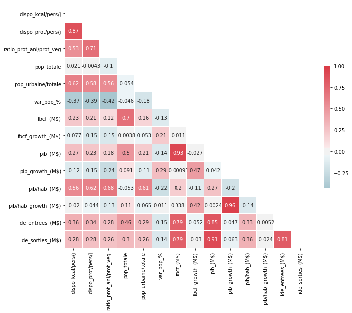

```python
# https://seaborn.pydata.org/examples/many_pairwise_correlations.html?highlight=correlation%20matrix
# Calculate the correlation matrix
corr = df_hc.loc[:,'dispo_kcal/pers/j':].corr()

# Generate a mask for the upper triangle
mask = np.zeros_like(corr, dtype=np.bool)
mask[np.triu_indices_from(mask)] = True

# Set up the matplotlib figure
f, ax = plt.subplots(figsize=(11, 9))

# Generate a custom diverging colormap
cmap = sns.diverging_palette(220, 10, as_cmap=True)

# Draw the heatmap with the mask and correct aspect ratio
sns.heatmap(corr, mask=mask, cmap=cmap, center=0, annot=True,
            square=True, linewidths=.5, cbar_kws={"shrink": .5})

plt.show()
```

Notre matrice des corrélations nous donne l'occasion d'entreprendre du "feature engineering". Selon Marcelin Berthelot, le "feature engineering" est composé de trois tâches principales :

- Transformation de la donnée pour être exploitée au mieux par les algorithmes d’apprentissage.
- Extraction des informations pertinentes et informatives cachées dans les données.
- Sélection de variables explicatives.

Ici, nous voulons déterminer quelles variables garder pour notre classification non-supervisée. C'est pourquoi, nous allons visualiser les nuages de points des attributs corrélés à plus de 90%. Si nous détectons une relation linéaire, nous pouvons supprimer un des deux éléments.

Sources :

- https://www.college-de-france.fr/site/stephane-mallat/seminar-2018-02-21-11h15.htm
- https://www.journaldunet.com/solutions/expert/69609/le-feature-engineering--futur-du-data-scientist.shtml

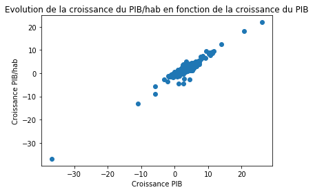

```python
plt.scatter(df_hc["pib_growth_(M$)"], df_hc["pib/hab_growth_(M$)"])
plt.xlabel("Croissance PIB")
plt.ylabel("Croissance PIB/hab")
plt.title("Evolution de la croissance du PIB/hab en fonction de la croissance du PIB")
plt.show()
```

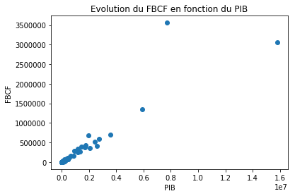

```python
plt.scatter(df_hc["pib_(M$)"], df_hc["fbcf_(M$)"])
plt.xlabel("PIB")
plt.ylabel("FBCF")
plt.title("Evolution du FBCF en fonction du PIB")
plt.show()
```

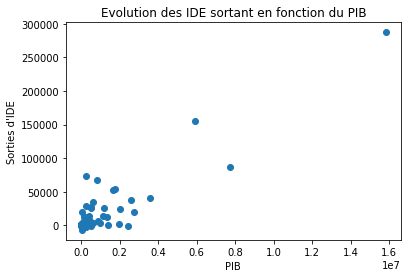

```python
plt.scatter(df_hc["pib_(M$)"], df_hc["ide_sorties_(M$)"])
plt.xlabel("PIB")
plt.ylabel("Sorties d'IDE")
plt.title("Evolution des IDE sortant en fonction du PIB")
plt.show()
```

Commentaires sur la matrice des corrélations :

- Les variables *pib*growth*(M\$)* et *pib/hab*growth*(M\$)* sont corrélées à 96% et ont une relation parfaitement linéaires. Ce qui est normal car elles délivrent une information similaire. Je peux donc supprimer une de ces deux variables.
- *pib_(M\$)* et *fbcf_(M\$)* ont une relation linéaire si l'on excepte la présence d'un outlier. Je vais donc supprimer *fbcf_(M\$)*
- *pib_(M\$)* et *ide*sorties*(M\$)* ont une relation linéaire mais la variabilité est assez importante donc je préfère garder les deux attributs.

Par curiosité je vais regarderl'évolution des IDE sortants en fonction des IDE entrants.

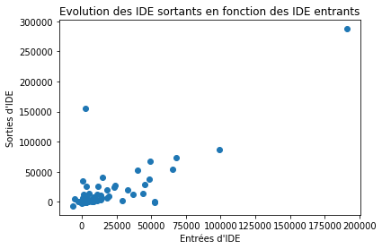

```python
plt.scatter(df_hc["ide_entrees_(M$)"], df_hc["ide_sorties_(M$)"])
plt.xlabel("Entrées d'IDE")
plt.ylabel("Sorties d'IDE")
plt.title("Evolution des IDE sortants en fonction des IDE entrants")
plt.show()
```

```python
# Détection des outliers
df_hc[df_hc["ide_sorties_(M$)"] > 150000]
```

|  | pays | groupe_pays | dispo_kcal/pers/j | dispo_prot/pers/j | ratio_prot_ani/prot_veg | pop_totale | pop_urbaine/totale | var_pop_% | fbcf_(M$) | fbcf_growth_(M$) | pib_(M$) | pib_growth_(M$) | pib/hab_(M$) | pib/hab_growth_(M$) | ide_entrees_(M$) | ide_sorties_(M$) |
| --- | --- | --- | --- | --- | --- | --- | --- | --- | --- | --- | --- | --- | --- | --- | --- | --- |
| 77 | Japon | Asie | 2726.0 | 87.65 | 1.235969 | 128312920.0 | 0.924911 | -0.088349 | 1.342859e+06 | 4.932181 | 5.894237e+06 | 2.000490 | 45936.429380 | 2.090686 | 2633.71 | 155193.77 |
| 157 | États-Unis d'Amérique | Amériques | 3682.0 | 109.42 | 1.759647 | 315536676.0 | 0.812773 | 0.702523 | 3.056111e+06 | 3.049612 | 1.580286e+07 | 1.677334 | 50082.467437 | 0.968011 | 190670.82 | 287277.25 |

La situation du Japon peut paraître étonnante mais selon des rapports du gouvernement français commentant l'investissement japonais en 2012 :

> - Le Japon demeure la 2e source mondiale d’investissements directs, avec une progression de 7% des flux sortants en 2012
> - Le Japon reste peu ouvert à l’investissement étranger, avec un stock d’IDE reçu équivalent à 3,7% du PIB, soit le plus faible ratio des pays développés. Le gouvernement Abe souhaite favoriser l’investissement étranger dans le cadre de sa stratégie de croissance.

Dès 2014, les IDE entrants japonais atteignirent 14672,75 millions de Dollars selon les données de la FAO.

Sources :

- https://www.diplomatie.gouv.fr/IMG/pdf/JAPON_-_Les_investissements_directs_etrangers_sortants_cle81d66a.pdf
- https://www.diplomatie.gouv.fr/IMG/pdf/JAPON_-_Les_investissements_directs_etrangers_sortants_cle81d66a.pdf
- http://www.fao.org/faostat/fr/#data/FDI

### Centrage-réduction et lancement de la classification hiérarchique

Pour le classification hiérarchique, je vais centrer-réduire les données car mes variables sont exprimées dans des unités différentes. Selon *Statsoft*, la standardisation (action de centrer-réduire) :

> fait référence à la transformation de données en soustrayant à chaque valeur une valeur de référence (classiquement une moyenne d'échantillon) et en la divisant par l'écart-type (typiquement un EcT d'échantillon). Cette importante transformation rendra toutes les valeurs (indifféremment de leurs distributions et unités de mesures originales) en unités compatibles avec distribution de moyenne 0 et d'écart-type 1.

Sources :

- https://fr.wikipedia.org/wiki/Variable_centr%C3%A9e_r%C3%A9duit
- http://www.statsoft.fr/concepts-statistiques/glossaire/c/centrer.html

```python
# Suppression des attributs inutiles
df_hc = df_hc.drop(["pib_growth_(M$)", "fbcf_(M$)"], 1)

X = df_hc.values[:,2:] # On supprime les deux premières colonnes
print("X : ")
print(X)
print(X.shape)

# Centrage-réduction
X = X.astype(np.float64) # conversion des nombres entiers en nombres décimaux (float) : necessaire pour le StandardScaler
std_scaler = preprocessing.StandardScaler().fit(X) # Calcule la moyenne et l'écart-type pour le centrage-réduction
X_scaled = std_scaler.transform(X) # Centre et réduit
print("\nX_scaled : ")
print(X_scaled)
print(X_scaled.shape)

# Clustering hiérarchique
Z = linkage(X_scaled, 'ward')
print("\nZ : ")
print(Z)
print(Z.shape)
```

```
X :
[[2924.0 90.05999999999999 0.9235369500213587 ... 2.844251 355.88 27.33]
 [2087.0 58.26000000000002 0.26514657980456013 ... 3.0037599999999998
  35.95 0.51]
 [3188.0 111.37 1.1433795227097767 ... 1.0387 1240.97 39.03]
 ...
 [2725.0 82.21000000000001 0.9444181646168404 ... 3.071759 1831.85 293.58]
 [3490.0 111.90000000000003 1.2935027669604429 ... 3.4320690000000003
  431.13 16.69]
 [2335.0 70.69000000000001 0.7037840443480354 ... 2.843301 1476.7 0.0]]
(172, 12)

X_scaled :
[[ 0.16775855  0.4347545   0.03504944 ...  0.16978261 -0.34229921
  -0.25654841]
 [-1.75250795 -1.16234218 -1.12602891 ...  0.2036494  -0.35821012
  -0.25751946]
 [ 0.773434    1.50501017  0.42274414 ... -0.21357018 -0.29828151
  -0.2561248 ]
 ...
 [-0.28879227  0.04050265  0.07187368 ...  0.21808688 -0.26889559
  -0.24690849]
 [ 1.46629002  1.53162845  0.68748806 ...  0.29458755 -0.33855684
  -0.25693365]
 [-1.1835401  -0.53806823 -0.35248712 ...  0.16958091 -0.28655807
  -0.25753793]]
(172, 12)

Z :
[[ 80.         146.           0.6000939    2.        ]
 [101.         151.           0.68576497   2.        ]
 [ 58.          62.           0.70556445   2.        ]
 [127.         172.           0.75392943   3.        ]
 [ 38.         140.           0.78002333   2.        ]
 [ 43.         121.           0.79813137   2.        ]
 [ 20.         160.           0.80718114   2.        ]
 [134.         148.           0.81662036   2.        ]
 [  1.         154.           0.82565225   2.        ]
 [165.         175.           0.85326096   4.        ]
 [ 21.          51.           0.85638354   2.        ]
```

[output cut: 146 more lines]

```
 [ 28.          67.           6.7589984    2.        ]
 [320.         322.           6.8552998   33.        ]
 [325.         327.           7.30129146  58.        ]
 [ 77.         324.           8.23093355  14.        ]
 [315.         328.           8.61781267  46.        ]
 [311.         332.           9.86865029  19.        ]
 [330.         334.          11.89090351  52.        ]
 [300.         333.          12.16872094  50.        ]
 [323.         331.          12.79935739  66.        ]
 [ 24.         336.          13.82786188  51.        ]
 [337.         338.          16.18272846 117.        ]
 [157.         329.          17.95054223   3.        ]
 [335.         340.          25.17350105  55.        ]
 [339.         341.          30.8130945  172.        ]]
(171, 4)
```

### Affichage et coupage du dendrogramme

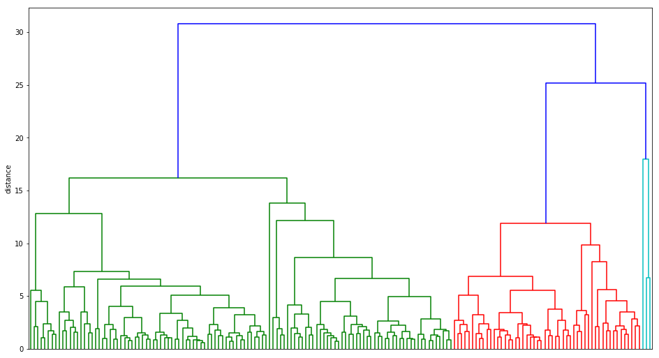

```
Nb d'observations dans chaque groupe :
```

```
1    66
3    52
2    51
4     2
5     1
Name: groupe_ch, dtype: int64
```

```python
# Affichage du dendrogramme
plt.figure(figsize=(16, 9))
plt.ylabel('distance')
dendrogram(Z, no_labels=True)
plt.show()

# Coupage du dendrogramme en 5 clusters
final_clusters = fcluster(Z, t=5, criterion='maxclust')
df_hc['groupe_ch'] = final_clusters
print("Nb d'observations dans chaque groupe : ")
df_hc['groupe_ch'].value_counts()
```

```python
# Pour savoir ce qu'il y a dans chaque groupe
print(df_hc.loc[df_hc['groupe_ch'].isin([1]), ['pays', 'groupe_ch']].head(10))
print(df_hc.loc[df_hc['groupe_ch'].isin([2]), ['pays', 'groupe_ch']].head(10))
print(df_hc.loc[df_hc['groupe_ch'].isin([3]), ['pays', 'groupe_ch']].head(10))
print(df_hc.loc[df_hc['groupe_ch'].isin([4, 5]), ['pays', 'groupe_ch']])
```

```
                               pays  groupe_ch
1                       Afghanistan          1
4                            Angola          1
11                       Bangladesh          1
13  Bolivie (État plurinational de)          1
14                         Botswana          1
16                           Belize          1
17                     Îles Salomon          1
20                          Myanmar          1
21                         Cameroun          1
23                       Cabo Verde          1
                         pays  groupe_ch
0                     Arménie          2
3                     Algérie          2
5          Antigua-et-Barbuda          2
```

[output cut: 22 more lines]

Il n'est pas étonnant que les Etats-Unis, l’Inde et la Chine soient à part car ce sont des pays atypiques que ce soit au niveau de la population, du PIB ou des IDE.

### Exportations et caractérisation des groupes

```python
# Exportation de la liste des pays avec le groupe associé
df_hc[['pays', 'groupe_ch']].to_csv('num_groupe_pays.csv', index=False)

# Copie des données pour calculer centroïdes
df_centroids = df_hc[['pays', 'groupe_ch']].copy()
col_index = 2

for column in X_scaled.T:
    col_name = df_hc.columns[col_index]
    df_centroids[col_name] = column # Copie de la colonne dans df
    col_index = col_index + 1

# Vérifs que les données ont été copiées correctement
assert X_scaled[0, 0] == df_centroids.iat[0, 2]
assert X_scaled[-1, -1] == df_centroids.iat[-1,-1]

# Agrégation des données pour avoir le centroïde de chaque groupe
df_centroids = df_centroids.groupby('groupe_ch', as_index=False).mean()

# Exportation des centroïdes
df_centroids.to_csv('position_centroides.csv', index=False)
df_centroids
```

|  | groupe_ch | dispo_kcal/pers/j | dispo_prot/pers/j | ratio_prot_ani/prot_veg | pop_totale | pop_urbaine/totale | var_pop_% | fbcf_growth_(M$) | pib_(M$) | pib/hab_(M$) | pib/hab_growth_(M$) | ide_entrees_(M$) | ide_sorties_(M$) |
| --- | --- | --- | --- | --- | --- | --- | --- | --- | --- | --- | --- | --- | --- |
| 0 | 1 | -0.898882 | -0.894067 | -0.805078 | -0.081604 | -0.766895 | 0.565654 | 0.318581 | -0.242640 | -0.622896 | 0.323511 | -0.312340 | -0.247967 |
| 1 | 2 | 0.164880 | 0.060356 | 0.047282 | -0.177253 | 0.074389 | -0.057367 | -0.179072 | -0.209147 | -0.288967 | -0.233870 | -0.241494 | -0.211496 |
| 2 | 3 | 0.948501 | 1.053204 | 0.976587 | -0.095666 | 0.905553 | -0.636892 | -0.225745 | 0.197050 | 1.057692 | -0.210387 | 0.348878 | 0.275571 |
| 3 | 4 | -0.155727 | -0.121718 | -0.784138 | 8.766304 | -0.662226 | -0.384270 | -0.036636 | 3.006770 | -0.533673 | 0.872148 | 2.833201 | 1.339357 |
| 4 | 5 | 1.906781 | 1.407075 | 1.509538 | 1.867799 | 1.056999 | -0.520468 | -0.081654 | 10.420613 | 1.915784 | -0.228579 | 9.122531 | 10.143702 |

Voici l'interprétation des centroïdes de chaque groupe :

1. Ce sont des pays dont la population et le PIB/hab augmentent. De plus, ils consomment moins de protéines et de calories que les quatres autres rassemblements. **C'est la cible idéale pour nos exportations**.
2. Groupe des pays proche de la moyenne pour chaque variable.
3. Ces pays ont déjà un accès important à des protéines et des calories. En outre, bien que leur PIB/hab soit important, leur croissance est plus faible que ceux du groupe 1. Ce sont des pays développés, ils ne sont pas propices à une insertion dans le marché du poulet.
4. Cet ensemble regroupe l'Inde et la Chine continentale qui ont chacun la particularité d'avoir une population bien supérieure au reste des pays.
5. Ne contient que les Etats-Unis. C'est un pays atypique sur la plupart des variables mais plus particulièrement en ce qui concerne le PIB et les IDE. Il n'est pas judicieux de vendre du poulet là-bas.

## ACP et visualisation des partitions

L’analyse en composantes principales (ACP) sert à réduire le nombre de dimensions d'un jeu de données tout en gardant le plus d'informations. Elle transforme un certain nombre de variables (éventuellement) corrélées en un nombre (plus petit) de variables non-corrélées appelées composantes principales. La première composante principale explique autant que possible la variabilité dans les données, et chaque composante suivante explique autant que possible la variabilité restante.

Dans notre cas, nous effectuons une ACP pour visualiser les pays dans le premier plan factoriel. Ainsi, nous espérons mieux intérpréter nos partitions.

Sources :

- https://plot.ly/ipython-notebooks/principal-component-analysis/
- https://towardsdatascience.com/pca-using-python-scikit-learn-e653f8989e60
- https://www.youtube.com/watch?v=uV5hmpzmWsU
- https://www.youtube.com/watch?v=KrNbyM925wI&list=PLnZgp6epRBbRn3FeMdaQgVsFh9Kl0fjqX
- https://medium.com/data-design/how-to-not-be-dumb-at-applying-principal-component-analysis-pca-6c14de5b3c9d

```
X_projected :
[[ 0.04265939 -0.7320434   0.30473648 ...  0.17749101  0.18660519
  -0.04345243]
 [-2.72244681  1.10385121  0.75832942 ... -0.0216547   0.26662703
  -0.10341051]
 [ 0.77991437 -1.1830444   0.19900501 ...  0.28918978  0.44044125
  -0.09494738]
 ...
 [-0.15738416 -0.55841505  0.71520223 ...  0.0187112   0.1788643
  -0.06006952]
 [ 1.18947839 -1.37025753 -0.73936054 ...  0.33011084  0.01730422
   0.03756321]
 [-1.75626804  0.59535735  0.13573751 ...  0.04408112  0.23546632
  -0.09420652]]
(172, 12)
```

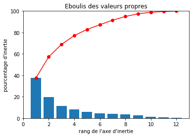

```python
# Calcul des composantes principales
pca = decomposition.PCA()
pca.fit(X_scaled) # Ajuste le modèle avec X
X_projected = pca.transform(X_scaled) # Applique la réduction de dimensionnalité à X
print("\nX_projected : ")
print(X_projected)
print(X_projected.shape)

# Affichage des éboulis
eboulis = pca.explained_variance_ratio_*100
plt.bar(np.arange(len(eboulis))+1, eboulis)
plt.plot(np.arange(len(eboulis))+1, eboulis.cumsum(),c="red",marker='o')
plt.ylim(0,100)
plt.xlabel("rang de l'axe d'inertie")
plt.ylabel("pourcentage d'inertie")
plt.title("Eboulis des valeurs propres")
plt.show()
```

```
          pays  groupe_ch     dim_1     dim_2     dim_3
0      Arménie          2  0.042659 -0.732043  0.304736
1  Afghanistan          1 -2.722447  1.103851  0.758329
2      Albanie          3  0.779914 -1.183044  0.199005
3      Algérie          2 -0.077592 -0.328145 -0.353326
4       Angola          1 -2.063466  0.657539  0.425308
```

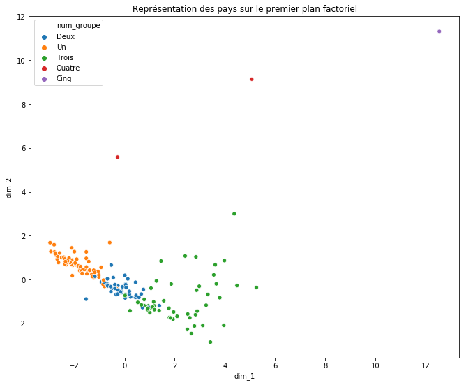

```python
# Coordonnées des individus
df_acp = df_hc[['pays', 'groupe_ch']].copy()
for i in range(0, 3) :
    df_acp['dim_' + str(i + 1)] = X_projected[:, i]

# Vérification de l'opération
print(df_acp.head())

# Je suis obligé de créer une nouvelle colonne pour mon graphique
# Seaborn produit une légende fausse si j'use de 'groupe_ch'
# Plus de détails: https://github.com/mwaskom/seaborn/issues/1515
df_acp['num_groupe'] = df_acp['groupe_ch']
df_acp = df_acp.replace({
    'num_groupe' : {
        1 : 'Un',
        2 : 'Deux',
        3 : 'Trois',
        4 : 'Quatre',
        5 : 'Cinq'
    }
})

# Représentation des individus sur le premier plan factoriel
f, ax = plt.subplots(figsize=(11, 9))
ax = sns.scatterplot(x="dim_1", y="dim_2",
                     hue="num_groupe", data=df_acp)
plt.title("Représentation des pays sur le premier plan factoriel")
plt.show()
```

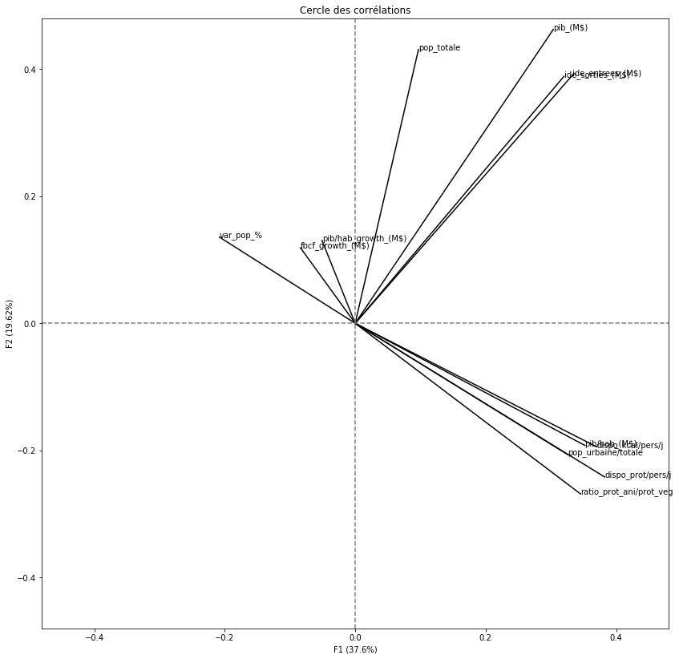

```python
# Création du cercle des corrélations
pcs = pca.components_

# Définition de la taille du graphique
plt.figure(figsize=(14, 14))
corr_graph_size = [-0.48, 0.48]

for i, (x, y) in enumerate(zip(pcs[0, :], pcs[1, :])):
    # Afficher un segment de l'origine au point (x, y)
    plt.plot([0, x], [0, y], color='k')
    # Afficher le nom (data.columns[i]) de la performance
    plt.text(x, y, df_hc.columns[i + 2], fontsize='10')


# Afficher une ligne horizontale y=0
plt.plot(corr_graph_size, [0, 0], color='grey', ls='--')

# Afficher une ligne verticale x=0
plt.plot([0, 0], corr_graph_size, color='grey', ls='--')

plt.xlim(corr_graph_size)
plt.ylim(corr_graph_size)
plt.xlabel("F1 (" + str(round(pca.explained_variance_ratio_[0] * 100, 2)) + "%)")
plt.ylabel("F2 (" + str(round(pca.explained_variance_ratio_[1] * 100, 2)) + "%)")
plt.title("Cercle des corrélations")

plt.show()
```

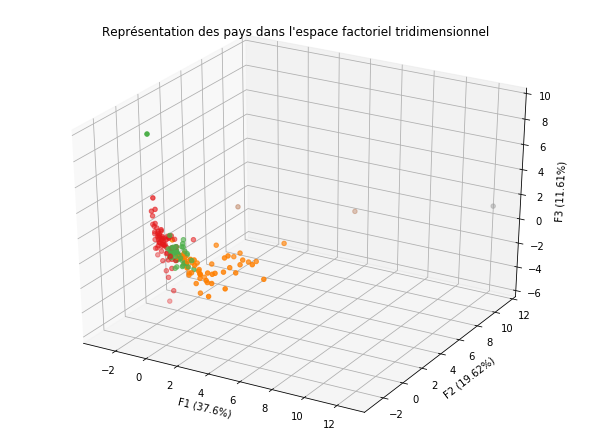

```python
from mpl_toolkits.mplot3d import Axes3D # Pour créer des graphiques en 3D

# Pour mieux comprendre l'intéraction entre les dimensions
# Viusalisation des trois premières dimensions de l'ACP
fig = plt.figure(1, figsize=(8, 6))
ax = Axes3D(fig)

ax.scatter(df_acp["dim_1"], df_acp["dim_2"], df_acp["dim_3"],
           c=df_acp["groupe_ch"], cmap=plt.cm.Set1)

ax.set_title("Représentation des pays dans l'espace factoriel tridimensionnel")
ax.set_xlabel("F1 (" + str(round(pca.explained_variance_ratio_[0] * 100, 2)) + "%)")
ax.set_ylabel("F2 (" + str(round(pca.explained_variance_ratio_[1] * 100, 2)) + "%)")
ax.set_zlabel("F3 (" + str(round(pca.explained_variance_ratio_[2] * 100, 2)) + "%)")

plt.show()
```

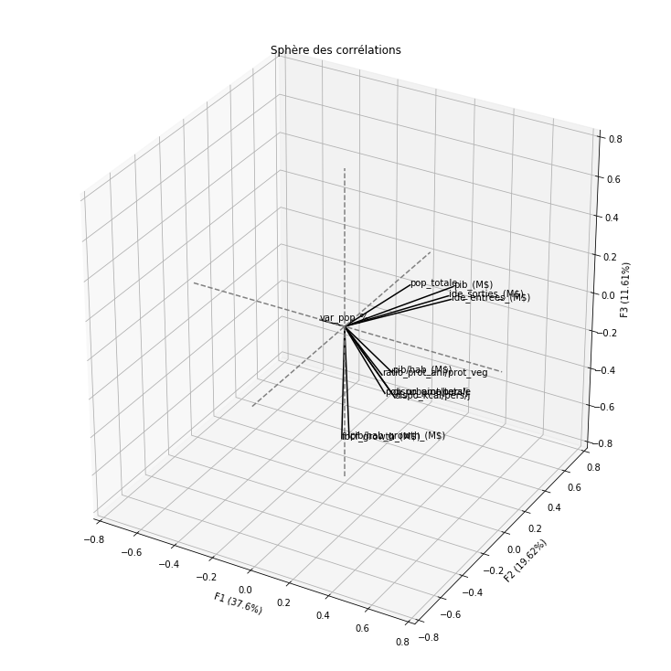

```python
# Définition de la taille du graphique
fig = plt.figure(figsize=(10, 10))
ax = Axes3D(fig)

corr_graph_size = [-0.8, 0.8]

for i, (x, y, z) in enumerate(zip(pcs[0, :], pcs[1, :], pcs[2, :])):
    # Afficher un segment de l'origine au point (x, y)
    ax.plot([0, x], [0, y], [0, z], color='k')
    # Afficher le nom (data.columns[i]) de la performance
    ax.text(x, y, z, df_hc.columns[i + 2], fontsize='10')


# Afficher une ligne horizontale y=0
ax.plot(corr_graph_size, [0, 0], [0, 0], color='grey', ls='--')

# Afficher une ligne verticale x=0
ax.plot([0, 0], corr_graph_size, [0, 0], color='grey', ls='--')

ax.plot([0, 0], [0, 0], corr_graph_size, color='grey', ls='--')

ax.set_xlim3d(corr_graph_size)
ax.set_ylim3d(corr_graph_size)
ax.set_zlim3d(corr_graph_size)

ax.set_xlabel("F1 (" + str(round(pca.explained_variance_ratio_[0] * 100, 2)) + "%)")
ax.set_ylabel("F2 (" + str(round(pca.explained_variance_ratio_[1] * 100, 2)) + "%)")
ax.set_zlabel("F3 (" + str(round(pca.explained_variance_ratio_[2] * 100, 2)) + "%)")
ax.set_title("Sphère des corrélations")

plt.show()
```

```python
# Pour mieux comprendre l'ACP
# Indivs min et max de la première dimension factorielle
print(df_acp.iloc[df_acp[['dim_1']].idxmin()])
print(df_acp.iloc[df_acp[['dim_1']].idxmax()])

# Indivs min et max de la deuxième dimension factorielle
print(df_acp.iloc[df_acp[['dim_2']].idxmin()])
print(df_acp.iloc[df_acp[['dim_2']].idxmax()])

# Indivs min et max de la troisième dimension factorielle
print(df_acp.iloc[df_acp[['dim_3']].idxmin()])
print(df_acp.iloc[df_acp[['dim_3']].idxmax()])
```

```
           pays  groupe_ch     dim_1     dim_2     dim_3 num_groupe
102  Mozambique          1 -2.965993  1.682945 -1.960515         Un
                      pays  groupe_ch      dim_1      dim_2     dim_3  \
157  États-Unis d'Amérique          5  12.539692  11.313832  1.272909

    num_groupe
157       Cinq
       pays  groupe_ch     dim_1     dim_2     dim_3 num_groupe
66  Islande          3  3.420961 -2.850515 -0.984973      Trois
                      pays  groupe_ch      dim_1      dim_2     dim_3  \
157  États-Unis d'Amérique          5  12.539692  11.313832  1.272909

    num_groupe
157       Cinq
    pays  groupe_ch     dim_1     dim_2     dim_3 num_groupe
70  Iraq          1 -2.104371  1.445299 -5.439303         Un
                         pays  groupe_ch     dim_1     dim_2     dim_3  \
24  République centrafricaine          2 -1.535259 -0.888612  9.333785

   num_groupe
24       Deux
```

**Interprétations des dimensions de l'ACP**

1. La première composante principale est la plus corrélée avec : dispo_kcal/pers/j, dispo_prot/pers/j, pib/hab, pop_urbaine/pop_totale. On peut l'interpréter comme étant le **niveau de développement du pays**. -> Nous devons choisir des pays qui ont des valeurs faibles sur cet axe.
2. Les variables les plus corrélées à cette axe sont la population totale et le PIB. Cette dimension rend compte de la **puissance démographique et économique du pays**.
3. var*pop*% semble proche dans le premier plan factoriel de fbcf_growth et pib_growth. Cependant, on voit que ce n'est pas le cas quand on visualise les trois premières dimensions grâce à la commande *%matplotlib notebook*. fbcf_growth et pib_growth sont très corrélées négativement avec la troisième composante principale. Par conséquent celle-ci rend compte de la **croissance économique d'un pays**. -> Nous devons privilégier les pays qui ont des valeurs faibles sur cet axe.

Sources :

- http://www.jybaudot.fr/Analdonnees/acpvarres.html
- http://www.foad-mooc.auf.org/IMG/pdf/M04-4.pdf

## Test d'adéquation

Nous allons utiliser test de D'Agostino comme test d'adéquation. Il sert à vérifier si la distribution d'un échantillion ressemble à la distribution normale. L’hypothèse nulle est que les valeurs sont distribuées normalement.

Sources :

- https://machinelearningmastery.com/a-gentle-introduction-to-normality-tests-in-python/
- https://docs.scipy.org/doc/scipy/reference/generated/scipy.stats.normaltest.html

```
p = 0.0314747
L'hypothèse nulle ne peut pas être rejetée : la distribution suit la loi normale
```

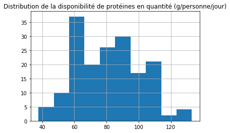

```python
from scipy import stats

k2, p_value = stats.normaltest(df_hc["dispo_prot/pers/j"])
alpha = 1e-3

print("p = {:g}".format(p_value))

if p_value < alpha:
    print("L'hypothèse nulle peut être rejetée : la distribution ne suit pas la loi normale")
else:
    print("L'hypothèse nulle ne peut pas être rejetée : la distribution suit la loi normale")

df_hc[["dispo_prot/pers/j"]].hist()
plt.title("Distribution de la disponibilité de protéines en quantité (g/personne/jour)")
plt.show()
```

## Test de comparaison de deux populations (dans le cas gaussien)

Je vais utiliser deux tests de comparaisons :

- Je dois d'abord tester l'égalité des variances grâce au test de Bartlett. Il est nécessaire pour le test suivant.
- Ensuite je vais comparer deux moyennes dans le cas Gaussien grâce au test de Student.

Sources :

- https://docs.scipy.org/doc/scipy-0.15.1/reference/generated/scipy.stats.ttest_ind.html
- https://docs.scipy.org/doc/scipy-0.14.0/reference/generated/scipy.stats.bartlett.html#scipy.stats.bartlett
- https://stackoverflow.com/questions/25064506/what-scipy-statistical-test-do-i-use-to-compare-sample-means

```
p = 0.268762
L'hypothèse nulle ne peut pas être rejetée : les échantillions n'ont pas des variances significativement différentes
```

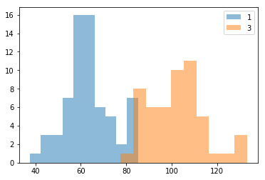

```python
sample1 = df_hc.loc[df_hc["groupe_ch"] == 1,"dispo_prot/pers/j"]
sample2 = df_hc.loc[df_hc["groupe_ch"] == 3,"dispo_prot/pers/j"]

# Test d'égalité des variances
# https://en.wikipedia.org/wiki/Bartlett%27s_test

t_stat, p_value = stats.bartlett(sample1, sample2)
alpha = 1e-3

print("p = {:g}".format(p_value))

if p_value < alpha:  # null hypothesis: all input samples are from populations with equal variances
    print("L'hypothèse nulle peut être rejetée : les échantillions ont des variances significativement différentes")
else:
    print("L'hypothèse nulle ne peut pas être rejetée : les échantillions n'ont pas des variances significativement différentes")


# Affichage des deux distributions
plt.hist(sample1, alpha=0.5, label='1')
plt.hist(sample2, alpha=0.5, label='3')
plt.legend(loc='upper right')
plt.show()
```

```python
t_stat, p_value = stats.ttest_ind(sample1, sample2, equal_var=True)
alpha = 1e-3

print("p = {:g}".format(p_value))

if p_value < alpha: # null hypothesis: all input samples are from populations with equal variances
    print("L'hypothèse nulle peut être rejetée : les moyennes des deux populations sont significativement différentes")
else:
    print("L'hypothèse nulle ne peut pas être rejetée : les moyennes des populations ne sont pas significativement différentes")
```

```
p = 6.11189e-37
L'hypothèse nulle peut être rejetée : les moyennes des deux populations sont significativement différentes
```

## Pour enrichir et poursuivre l'étude

Nous avons réussi la mission proposée par notre entreprise. Toutefois, notre travail n'est qu'un point de départ. Durant mes rercherches, j'ai trouvé sur le site de la FAO des rubriques qui pourraient enrichir l'étude (j'ai adjoint les clés primaires) :

- **Cultures et produits animaux** : Intéressant car on y parle d'importations et d'exportations de poulets en boîte en valeur et en quantité.
  - Zone
  - Élément
  - Produit
  - Année
- **Animaux Vivants** : regroupe les infos concernant les animaux vivants exportés et importés. Ici on a les montants en valeur et en quantité.
  - Zone
  - Élément
  - Produit
  - Année
- **Matrices du commerce détaillées** : Donne le détail des exportations et des importations de produits de chaque pays vers chaque pays. La table "bilans alimentaires" n'est pas aussi détaillée. Cette rubrique ne distingue pas les animaux vivants et morts. Elle semble faire doublon avec la rubrique "Cultures et produits animaux" mais elle contient en plus des informations concernant les imports et exports de poulet.
  - Pays déclarants
  - Pays partenaires
  - Élément
  - Produit
  - Année
- **Élevage primaire** : Pour connaître la production animalière.
  - Zone
  - Élément
  - Produit
  - Année
- **Prix à la Production - Annuels** : Prix des produits à la sortie de la ferme. Cette table pourrait servir à comparer notre compétitivité par rapport aux pays ciblés.
  - Zone
  - Élément
  - Produit
  - Année
- **Tendances dans l’élevage** : Utile en combinaison des deux rubriques précédentes.
  - Zone
  - Élément
  - Produit
  - Année